# Indicators of transparency: Analysis across PMCOA

Stylianos Serghiou

06/06/2020

# Setup

```r
# Load packages
library(broom)
library(corrplot)
library(magrittr)
library(readxl)
library(tidyverse)
library(vroom)

# Import data
meta <- vroom("../../data/tidy_data/pmcoa-meta-data_all.csv")
pmcoa <- vroom("../../data/tidy_data/indicators_all.csv")

# Import validation data (out_data, out_code, out_coi, out_fund, out_register)
data_output <- "../../../3_algorithm-validation/output/data_output"
load(file.path(data_output, "paper_eval-lists.RData"))
```

A function to easily create counts and proportions.

```r
sum_prop <- function(x, p, at = F) {

  if (at) {

    x_sum <- sum(x == p)
    x_prop <- mean(x == p) * 100

  } else {

    x_sum <- sum(x >= p)
    x_prop <- mean(x >= p) * 100

  }

  sprintf("%s (%.1f%%)", x_sum, x_prop)
}
```

A function to create a summary table for numeric features.

```r
tabulate_nums <- function(.data,
                          indicator_var = indicator_vars[1],
                          num_vars = num_vars_meta) {

  .data %>%
    filter(year >= 2000) %>%
    pivot_longer(
      cols = c(!!! num_vars),
      names_to = "vars",
      values_to = "vals") %>%
    mutate(vars = recode(vars, !!! dic)) %>%
    group_by(vars) %>%
    mutate(p_value = kruskal.test(vals ~ !!! indicator_var)$p.value) %>%
    group_by(vars, !!! indicator_var, p_value) %>%
    summarise_at(vars(vals), list(
      mean = ~ mean(., na.rm = T),
      SD = ~ sd(., na.rm = T),
      Q1 = ~ quantile(., probs = 0.25, na.rm = T),
      Q2 = ~ median(., na.rm = T),
      Q3 = ~ quantile(., probs = 0.75, na.rm = T),
      min = ~ min(., na.rm = T),
      max = ~ max(., na.rm = T),
      n_missing = ~ sum(is.na(.)),
      N = length
    )) %>%
    ungroup() %>%
    gather(indicator, value, !!! indicator_var) %>%
    mutate(indicator = recode(indicator, !!! dic)) %>%
    select(indicator, value,  everything()) %>%
    select(-p_value, p_value) %>%
    mutate_at(vars(Q1:Q3), formatC, digits = 0, format = "f")

}
```

A function to prettify the table of numeric features created above.

```r
prettify_num_table <- function(.data, indicator_var = indicator_vars[1]) {

  .data %>%
    mutate(vals = glue::glue("{Q2} ({Q1}-{Q3})")) %>%
    mutate(value = if_else(value, "Present", "Absent")) %>%
    select(1:3, vals, p_value) %>%
    mutate(indicator = fct_inorder(indicator)) %>%
    spread(value, vals) %>%
    select(-p_value, p_value) %>%
    mutate(p_value = formatC(p_value, format = "E", digits = 2))

}
```

Variable groupings and definitions.

```r
num_vars <- syms(c(
  "score",
  "year",
  "jif",
  "eigenfactor_score",
  "n_cite"
))

num_vars_meta <- syms(c(
  "n_auth",
  "n_affiliation",
  "n_ref",
  "n_fig",
  "n_table"
))

num_vars_dic <- c(
  "Indicator count" = "score",
  "Year" = "year",
  "Journal Impact Factor (WOS)" = "jif",
  "Eigenfactor (WOS)" = "eigenfactor_score",
  "Citation count (OCC)" = "n_cite"
)

num_vars_meta_dic <- c(
  "Number of authors" = "n_auth",
  "Number of affiliations" = "n_affiliation",
  "Number of references" = "n_ref",
  "Number of figures" = "n_fig",
  "Number of tables" = "n_table"
)


factor_vars <- syms(c(
  "journal",
  "publisher",
  "affiliation_country",
  "type",
  "field",
  "is_art"
))

factor_vars_meta <- syms(c(
  "is_supplement"
))

factor_vars_dic <- c(
  "Journal" = "journal",
  "Publisher" = "publisher",
  "Country of affiliation" = "affiliation_country",
  "Type of publication" = "type",
  "Field of science (SciTech)" = "field",
  "Research article (OCC)" = "is_art"
)

factor_vars_meta_dic <- c(
  "Has supplement" = "is_supplement"
)


indicator_vars <- syms(c(
  "is_data_pred",
  "is_code_pred",
  "is_coi_pred",
  "is_fund_pred",
  "is_register_pred"
))

indicator_vars_dic <- c(
  "Data sharing" = "is_data_pred",
  "Code sharing" = "is_code_pred",
  "COI disclosure" = "is_coi_pred",
  "Funding disclosure" = "is_fund_pred",
  "Protocol registration" = "is_register_pred"
)


indicator_text_vars <- syms(c(
  "data_text",
  "code_text",
  "coi_text",
  "fund_text",
  "register_text"
))

indicator_text_vars_dic <- c(
  "data_text" = "Data sharing",
  "code_text" = "Code sharing",
  "coi_text" = "COI disclosure",
  "fund_text" = "Funding disclosure",
  "register_text" = "Protocol registration"
)


filter_vars <- syms(c(
  "year"
))


dic <- c(
  score = "Indicator count",
  year = "Year",
  jif = "Journal Impact Factor (WOS)",
  eigenfactor_score = "Eigenfactor (WOS)",
  n_cite = "Citation count (OCC)",
  n_auth = "Number of authors",
  n_affiliation = "Number of affiliations",
  n_ref = "Number of references",
  n_fig = "Number of figures",
  n_table = "Number of tables",
  journal = "Journal",
  publisher = "Publisher",
  affiliation_country = "Country of affiliation",
  type = "Type of publication",
  field = "Field of science (SciTech)",
  is_art = "Research article (OCC)",
  is_supplement = "Has supplement",
  is_data_pred = "Data sharing",
  is_code_pred = "Code sharing",
  is_coi_pred = "COI disclosure",
  is_fund_pred = "Funding disclosure",
  is_register_pred = "Protocol registration"
)
```

Create table of prevalence correction.

```r
# Any article
performance_error <- list(
  is_data_pred = out_data$data_eval_active,
  is_code_pred = out_code$code_eval_active,
  is_coi_pred  = out_coi$coi_eval_any,
  is_fund_pred = out_fund$fund_eval_any,
  is_register_pred = out_register$reg_eval_any
) %>%
  bind_rows(.id = "indicator") %>%
  filter(metric %in% c("NPV", "PPV")) %>%
  mutate_at(vars(median:expected), magrittr::divide_by, 100) %>%
  mutate(value = if_else(metric == "PPV", "Yes", "No")) %>%
  gather(estimand, estimate, expected, lo, hi) %>%
  # pivot_wider(names_from = metric, values_from = median:hi) %>%
  mutate(indicator = recode(indicator, !!!dic))

# Research articles
performance_error_art <- list(
  is_data_pred = out_data$data_eval_active_art,
  is_code_pred = out_code$code_eval_active_art,
  is_coi_pred  = out_coi$coi_eval_any_art,
  is_fund_pred = out_fund$fund_eval_any_art,
  is_register_pred = out_register$reg_eval_any_art
) %>%
  bind_rows(.id = "indicator") %>%
  filter(metric %in% c("NPV", "PPV")) %>%
  mutate_at(vars(median:expected), magrittr::divide_by, 100) %>%
  mutate(value = if_else(metric == "PPV", "Yes", "No")) %>%
  gather(estimand, estimate, expected, lo, hi) %>%
  # pivot_wider(names_from = metric, values_from = median:hi) %>%
  mutate(indicator = recode(indicator, !!!dic))
```

# Prepare data

## PMC

Keep variables relevant to the current analysis.

```r
pmc <-
  pmcoa %>%
  filter(is_success) %>%
  select(
    pmcid_pmc,
    !!! filter_vars,
    !!! indicator_vars,
    ends_with("_text"),
    !!! num_vars,
    !!! factor_vars
  ) %>%
  mutate(pmcid_pmc = as.character(pmcid_pmc))
```

## Meta

```r
meta %<>%
  select(pmcid_pmc, pmid, doi, title, n_auth:is_supplement) %>%
  mutate_at(vars(pmcid_pmc, pmid), as.character) %>%
  mutate(n_fig = n_fig_body + n_fig_floats) %>%
  mutate(n_table = n_table_body + n_table_floats) %>%
  select(-c(n_fig_body:n_table_floats)) %>%
  select(-n_fig, -n_table, n_fig, n_table)

meta <-
  pmc %>%
  select(pmcid_pmc, year, ends_with("_pred"), !!!num_vars, !!!factor_vars) %>%
  inner_join(meta, by = "pmcid_pmc") %>%
  select(pmcid_pmc, pmid, doi, everything())
```

# Indicators

## Tables

All publications - all time.

```r
observed <-
  pmc %>%
  select(!!!indicator_vars) %>%
  gather() %>%
  mutate(key = recode(key, !!!dic)) %>%
  mutate(value = if_else(value, "Yes", "No")) %>%
  mutate(key = fct_relevel(key, "Data sharing")) %>%
  group_by(key) %>%
  count(value) %>%
  mutate(N = sum(n)) %>%
  mutate(p = scales::percent(n / N, accuracy = 0.1)) %>%
  ungroup()

corrected <-
  pmc %>%
  select(!!!indicator_vars) %>%
  gather() %>%
  mutate(key = recode(key, !!!dic)) %>%
  mutate(value = if_else(value, "Yes", "No")) %>%
  group_by(key) %>%
  count(value) %>%
  mutate(N = sum(n)) %>%
  left_join(performance_error, by = c("key" = "indicator", "value")) %>%
  mutate(true = n * estimate, false = n * (1 - estimate)) %>%
  gather(true_false, counts, true:false) %>%
  mutate(is_present = case_when(
    metric == "PPV" & true_false == "true" ~ "present",
    metric != "PPV" & true_false != "true" ~ "present",
    metric != "PPV" & true_false == "true" ~ "absent",
    metric == "PPV" & true_false != "true" ~ "absent"
  )) %>%
  pivot_wider(
    id_cols = c(key, estimand, N),
    names_from = is_present,
    values_from = counts,
    values_fn = list(counts = sum)
  ) %>%
  mutate(p = scales::percent(present / N, accurcy = 0.1)) %>%
  pivot_wider(id_cols = c(key), names_from = estimand, values_from = p) %>%
  mutate(p_corrected = glue::glue("{expected} ({hi}-{lo})")) %>%
  select(key, p_corrected) %>%
  ungroup()

indicator_counts <- full_join(observed, corrected)


indicator_counts %>%
  sable() %>%
  collapse_rows(columns = 6, valign = "top")
```

| key | value | n | N | p | p_corrected |  |  |
| --- | --- | --- | --- | --- | --- | --- | --- |
| Data sharing | No | 2507637 | 2751420 | 91.1% | 14.5% (11.0%-18.8%) |  |  |
| Data sharing | Yes | 243783 | 2751420 | 8.9% |  |  |  |
| Code sharing | No | 2718015 | 2751420 | 98.8% |  | 2.29% (1.29%-4.17%) |  |
| Code sharing | Yes | 33405 | 2751420 | 1.2% |  |  |  |
| COI disclosure | No | 864513 | 2751420 | 31.4% | 69.52% (68.87%-70.11%) |  |  |
| COI disclosure | Yes | 1886907 | 2751420 | 68.6% |  |  |  |
| Funding disclosure | No | 893398 | 2751420 | 32.5% |  |  | 67.91% (67.62%-68.30%) |
| Funding disclosure | Yes | 1858022 | 2751420 | 67.5% |  |  |  |
| Protocol registration | No | 2680951 | 2751420 | 97.4% | 2.542% (2.514%-2.593%) |  |  |
| Protocol registration | Yes | 70469 | 2751420 | 2.6% |  |  |  |

All publications - since 2000.

```r
observed <-
  pmc %>%
  select(year, !!!indicator_vars) %>%
  filter(year >= 2000) %>%
  gather(key, value, -year) %>%
  mutate(key = recode(key, !!!dic)) %>%
  mutate(value = if_else(value, "Yes", "No")) %>%
  mutate(key = fct_relevel(key, "Data sharing")) %>%
  group_by(key) %>%
  count(value) %>%
  mutate(N = sum(n)) %>%
  mutate(p = scales::percent(n / N, accuracy = 0.1)) %>%
  ungroup()

corrected <-
  pmc %>%
  select(year, !!!indicator_vars) %>%
  filter(year >= 2000) %>%
  gather(key, value, -year) %>%
  mutate(key = recode(key, !!!dic)) %>%
  mutate(value = if_else(value, "Yes", "No")) %>%
  group_by(key) %>%
  count(value) %>%
  mutate(N = sum(n)) %>%
  left_join(performance_error, by = c("key" = "indicator", "value")) %>%
  mutate(true = n * estimate, false = n * (1 - estimate)) %>%
  gather(true_false, counts, true:false) %>%
  mutate(is_present = case_when(
    metric == "PPV" & true_false == "true" ~ "present",
    metric != "PPV" & true_false != "true" ~ "present",
    metric != "PPV" & true_false == "true" ~ "absent",
    metric == "PPV" & true_false != "true" ~ "absent"
  )) %>%
  pivot_wider(
    id_cols = c(key, estimand, N),
    names_from = is_present,
    values_from = counts,
    values_fn = list(counts = sum)
  ) %>%
  mutate(p = scales::percent(present / N, accurcy = 0.1)) %>%
  pivot_wider(id_cols = c(key), names_from = estimand, values_from = p) %>%
  mutate(p_corrected = glue::glue("{expected} ({hi}-{lo})")) %>%
  select(key, p_corrected) %>%
  ungroup()

indicator_counts_2000 <- full_join(observed, corrected)

indicator_counts_2000 %>%
  sable() %>%
  collapse_rows(columns = 6, valign = "top")
```

| key | value | n | N | p | p_corrected |  |  |
| --- | --- | --- | --- | --- | --- | --- | --- |
| Data sharing | No | 2258054 | 2498496 | 90.4% | 15.2% (11.7%-19.4%) |  |  |
| Data sharing | Yes | 240442 | 2498496 | 9.6% |  |  |  |
| Code sharing | No | 2466289 | 2498496 | 98.7% |  | 2.36% (1.37%-4.23%) |  |
| Code sharing | Yes | 32207 | 2498496 | 1.3% |  |  |  |
| COI disclosure | No | 631540 | 2498496 | 25.3% | 75.46% (74.96%-75.89%) |  |  |
| COI disclosure | Yes | 1866956 | 2498496 | 74.7% |  |  |  |
| Funding disclosure | No | 657011 | 2498496 | 26.3% |  |  | 73.95% (73.76%-74.19%) |
| Funding disclosure | Yes | 1841485 | 2498496 | 73.7% |  |  |  |
| Protocol registration | No | 2428254 | 2498496 | 97.2% | 2.772% (2.754%-2.813%) |  |  |
| Protocol registration | Yes | 70242 | 2498496 | 2.8% |  |  |  |

Research articles - all time.

```r
observed <-
  pmc %>%
  filter(is_art) %>%
  select(!!!indicator_vars) %>%
  gather() %>%
  mutate(key = recode(key, !!!dic)) %>%
  mutate(value = if_else(value, "Yes", "No")) %>%
  mutate(key = fct_relevel(key, "Data sharing")) %>%
  group_by(key) %>%
  count(value) %>%
  mutate(N = sum(n)) %>%
  mutate(p = scales::percent(n / N, accuracy = 0.1)) %>%
  ungroup()

corrected <-
  pmc %>%
  filter(is_art) %>%
  select(!!!indicator_vars) %>%
  gather() %>%
  mutate(key = recode(key, !!!dic)) %>%
  mutate(value = if_else(value, "Yes", "No")) %>%
  group_by(key) %>%
  count(value) %>%
  mutate(N = sum(n)) %>%
  left_join(performance_error_art, by = c("key" = "indicator", "value")) %>%
  mutate(true = n * estimate, false = n * (1 - estimate)) %>%
  gather(true_false, counts, true:false) %>%
  mutate(is_present = case_when(
    metric == "PPV" & true_false == "true" ~ "present",
    metric != "PPV" & true_false != "true" ~ "present",
    metric != "PPV" & true_false == "true" ~ "absent",
    metric == "PPV" & true_false != "true" ~ "absent"
  )) %>%
  pivot_wider(
    id_cols = c(key, estimand, N),
    names_from = is_present,
    values_from = counts,
    values_fn = list(counts = sum)
  ) %>%
  mutate(p = scales::percent(present / N, accurcy = 0.1)) %>%
  pivot_wider(id_cols = c(key), names_from = estimand, values_from = p) %>%
  mutate(p_corrected = glue::glue("{expected} ({hi}-{lo})")) %>%
  select(key, p_corrected) %>%
  ungroup()

indicator_counts_art <- full_join(observed, corrected)

indicator_counts_art %>%
  sable() %>%
  collapse_rows(columns = 6, valign = "top")
```

| key | value | n | N | p | p_corrected |  |  |
| --- | --- | --- | --- | --- | --- | --- | --- |
| Data sharing | No | 2048619 | 2285193 | 89.6% | 14.7% (11.1%-18.9%) |  |  |
| Data sharing | Yes | 236574 | 2285193 | 10.4% |  |  |  |
| Code sharing | No | 2253115 | 2285193 | 98.6% |  | 2.7% (1.5%-5.1%) |  |
| Code sharing | Yes | 32078 | 2285193 | 1.4% |  |  |  |
| COI disclosure | No | 619314 | 2285193 | 27.1% | 73.91% (73.23%-74.54%) |  |  |
| COI disclosure | Yes | 1665879 | 2285193 | 72.9% |  |  |  |
| Funding disclosure | No | 604862 | 2285193 | 26.5% |  |  | 74.45% (73.77%-75.35%) |
| Funding disclosure | Yes | 1680331 | 2285193 | 73.5% |  |  |  |
| Protocol registration | No | 2218710 | 2285193 | 97.1% | 2.880% (2.853%-2.930%) |  |  |
| Protocol registration | Yes | 66483 | 2285193 | 2.9% |  |  |  |

Research articles - since 2000.

```r
observed <-
  pmc %>%
  filter(is_art & year >= 2000) %>%
  select(!!!indicator_vars) %>%
  gather() %>%
  mutate(key = recode(key, !!!dic)) %>%
  mutate(value = if_else(value, "Yes", "No")) %>%
  mutate(key = fct_relevel(key, "Data sharing")) %>%
  group_by(key) %>%
  count(value) %>%
  mutate(N = sum(n)) %>%
  mutate(p = scales::percent(n / N, accuracy = 0.1)) %>%
  ungroup()

corrected <-
  pmc %>%
  filter(is_art & year >= 2000) %>%
  select(!!!indicator_vars) %>%
  gather() %>%
  mutate(key = recode(key, !!!dic)) %>%
  mutate(value = if_else(value, "Yes", "No")) %>%
  group_by(key) %>%
  count(value) %>%
  mutate(N = sum(n)) %>%
  left_join(performance_error, by = c("key" = "indicator", "value")) %>%
  mutate(true = n * estimate, false = n * (1 - estimate)) %>%
  gather(true_false, counts, true:false) %>%
  mutate(is_present = case_when(
    metric == "PPV" & true_false == "true" ~ "present",
    metric != "PPV" & true_false != "true" ~ "present",
    metric != "PPV" & true_false == "true" ~ "absent",
    metric == "PPV" & true_false != "true" ~ "absent"
  )) %>%
  pivot_wider(
    id_cols = c(key, estimand, N),
    names_from = is_present,
    values_from = counts,
    values_fn = list(counts = sum)
  ) %>%
  mutate(p = scales::percent(present / N, accurcy = 0.1)) %>%
  pivot_wider(id_cols = c(key), names_from = estimand, values_from = p) %>%
  mutate(p_corrected = glue::glue("{expected} ({hi}-{lo})")) %>%
  select(key, p_corrected) %>%
  ungroup()

indicator_counts_art_2000 <- full_join(observed, corrected)

indicator_counts_art_2000 %>%
  sable() %>%
  collapse_rows(columns = 6, valign = "top")
```

| key | value | n | N | p | p_corrected |  |  |
| --- | --- | --- | --- | --- | --- | --- | --- |
| Data sharing | No | 1872345 | 2105646 | 88.9% | 16.4% (13.0%-20.5%) |  |  |
| Data sharing | Yes | 233301 | 2105646 | 11.1% |  |  |  |
| Code sharing | No | 2074740 | 2105646 | 98.5% |  | 2.53% (1.54%-4.38%) |  |
| Code sharing | Yes | 30906 | 2105646 | 1.5% |  |  |  |
| COI disclosure | No | 456778 | 2105646 | 21.7% | 78.92% (78.51%-79.26%) |  |  |
| COI disclosure | Yes | 1648868 | 2105646 | 78.3% |  |  |  |
| Funding disclosure | No | 440413 | 2105646 | 20.9% |  |  | 79.207% (79.116%-79.325%) |
| Funding disclosure | Yes | 1665233 | 2105646 | 79.1% |  |  |  |
| Protocol registration | No | 2039369 | 2105646 | 96.9% | 3.0813% (3.0760%-3.1094%) |  |  |
| Protocol registration | Yes | 66277 | 2105646 | 3.1% |  |  |  |

## COI

Number disclosing no COIs.

```r
no_coi_synonyms <- c(
  "\\b[Nn]o (|potential )(conflict(|s)|competing)",
  "\\b[Nn]o (|potential )(commercial|financial)",
  "(disclose|declare|report) (|that they have )(no\\b|nothing|none)",
  "None of",
  "(None|Nothing|Nil\\b) (declared|disclosed)",
  "Nothing to (declare|disclose|report)"
)

no_coi_regex <- paste(no_coi_synonyms, collapse = "|")
pmcoa %<>% mutate(is_no_coi = str_detect(coi_text, no_coi_regex))

pmcoa %>%
  filter(is_success) %>%
  count(is_coi_pred, is_no_coi) %>%
  group_by(is_coi_pred) %>%
  mutate(N = sum(n)) %>%
  mutate(p = scales::percent(n / sum(n), accuracy = 0.1)) %>%
  sable()
```

| is_coi_pred | is_no_coi | n | N | p |
| --- | --- | --- | --- | --- |
| FALSE |  | 864513 | 864513 | 100.0% |
| TRUE | FALSE | 355886 | 1886907 | 18.9% |
| TRUE | TRUE | 1531018 | 1886907 | 81.1% |
| TRUE |  | 3 | 1886907 | 0.0% |

## Funding

Number disclosing no funding.

```r
no_fund_synonyms <- c(
  "\\b[Nn]il\\.|\\b[Nn]one\\.",
  "\\b[Nn]o(\\s\\w+){0,2} (financial|funding|support|grant\\b)",
  "\\bnot (receive|obtain)(\\s\\w+){0,2} (financial|funding|support|grant\\b)",
  "\\b[Nn]ot funded"
)

no_fund_regex <- paste(no_fund_synonyms, collapse = "|")
pmcoa %<>%  mutate(is_no_fund = str_detect(fund_text, no_fund_regex))

pmcoa %>%
  filter(is_success) %>%
  count(is_fund_pred, is_no_fund) %>%
  group_by(is_fund_pred) %>%
  mutate(N = sum(n)) %>%
  mutate(p = scales::percent(n / sum(n), accuracy = 0.1)) %>%
  sable()
```

| is_fund_pred | is_no_fund | n | N | p |
| --- | --- | --- | --- | --- |
| FALSE |  | 893398 | 893398 | 100.0% |
| TRUE | FALSE | 1675513 | 1858022 | 90.2% |
| TRUE | TRUE | 182505 | 1858022 | 9.8% |
| TRUE |  | 4 | 1858022 | 0.0% |

## Plots

Indicator counts with algorithms vs. PMC.

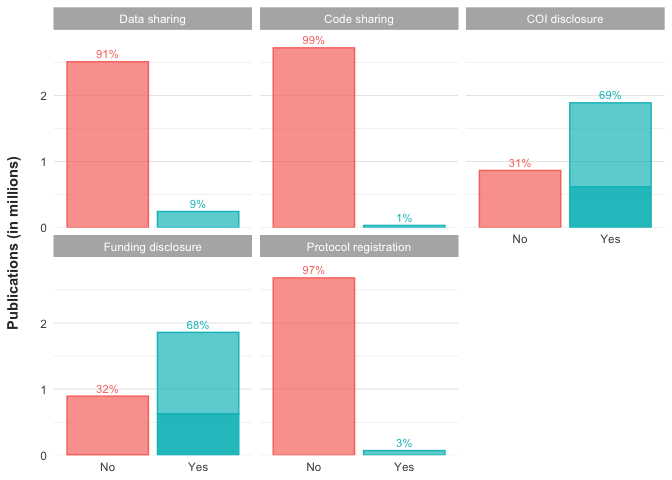

```r
indicator_counts_by_pmc <-
  pmcoa %>%
  filter(is_success) %>%
  select(ends_with("_pred"), starts_with("is_coi"), starts_with("is_fund")) %>%
  gather(Indicator, Value, !!!indicator_vars) %>%
  mutate(Value = if_else(Value, "Yes", "No")) %>%
  mutate(is_pmc = case_when(
    Indicator == "is_coi_pred" ~ is_coi_pmc_fn,
    Indicator == "is_fund_pred" ~ is_fund_pmc_group | is_fund_pmc_anysource
  )) %>%
  mutate(is_pmc = if_else(is.na(is_pmc), F, is_pmc)) %>%
  mutate(Indicator = recode(Indicator, !!!dic)) %>%
  group_by(Indicator) %>%
  mutate(N = n()) %>%
  add_count(Value) %>%
  mutate(p = scales::percent(n /N)) %>%
  ungroup()

indicator_counts_by_pmc %>%
  mutate(Indicator = fct_relevel(Indicator, "Data sharing")) %>%
  ggplot(aes(x = Value, fill = Value, color = Value)) +
  geom_bar(aes(alpha = is_pmc)) +
  geom_text(
    aes(y = ..count.., label = p),
    stat = 'count',
    size = 3,
    vjust = -0.5
  ) +
  scale_alpha_manual(values = c(0.7, 0.95)) +
  scale_y_continuous(
    breaks = seq(0, 3E6, 1E6),
    labels = seq(0, 3, 1),
    expand = expansion(mult = c(0, 0.1))
  ) +
  facet_wrap(~ Indicator) +
  labs(x = NULL, y = "Publications (in millions)\n") +
  theme(
    legend.position = "none",
    panel.grid.major.x = element_blank()
  )
```

```r
ggsave("../../output/figure_output/indicator-eval_indicator-counts-by-pmc.jpg")
```

## Correlation

Table for all articles.

```r
pmcoa %>%
  count(!!!indicator_vars, sort = T) %>%
  rename(!!!indicator_vars_dic) %>%
  mutate(N = sum(n)) %>%
  mutate(p = scales::percent(n / N, accuracy = 0.1)) %>%
  sable()
```

| Data sharing | Code sharing | COI disclosure | Funding disclosure | Protocol registration | n | N | p |
| --- | --- | --- | --- | --- | --- | --- | --- |
| FALSE | FALSE | TRUE | TRUE | FALSE | 1273382 | 2751420 | 46.3% |
| FALSE | FALSE | FALSE | FALSE | FALSE | 535428 | 2751420 | 19.5% |
| FALSE | FALSE | TRUE | FALSE | FALSE | 339233 | 2751420 | 12.3% |
| FALSE | FALSE | FALSE | TRUE | FALSE | 278282 | 2751420 | 10.1% |
| TRUE | FALSE | TRUE | TRUE | FALSE | 172393 | 2751420 | 6.3% |
| FALSE | FALSE | TRUE | TRUE | TRUE | 58456 | 2751420 | 2.1% |
| TRUE | FALSE | FALSE | TRUE | FALSE | 38515 | 2751420 | 1.4% |
| TRUE | TRUE | TRUE | TRUE | FALSE | 16020 | 2751420 | 0.6% |
| FALSE | TRUE | TRUE | TRUE | FALSE | 11426 | 2751420 | 0.4% |
| FALSE | FALSE | TRUE | FALSE | TRUE | 5722 | 2751420 | 0.2% |
| TRUE | FALSE | FALSE | FALSE | FALSE | 5336 | 2751420 | 0.2% |
| TRUE | FALSE | TRUE | FALSE | FALSE | 5181 | 2751420 | 0.2% |
| TRUE | FALSE | TRUE | TRUE | TRUE | 3713 | 2751420 | 0.1% |
| FALSE | TRUE | FALSE | TRUE | FALSE | 2290 | 2751420 | 0.1% |
| TRUE | TRUE | FALSE | TRUE | FALSE | 1791 | 2751420 | 0.1% |
| FALSE | FALSE | FALSE | TRUE | TRUE | 1494 | 2751420 | 0.1% |
| FALSE | FALSE | FALSE | FALSE | TRUE | 715 | 2751420 | 0.0% |
| FALSE | TRUE | TRUE | FALSE | FALSE | 711 | 2751420 | 0.0% |
| FALSE | TRUE | FALSE | FALSE | FALSE | 416 | 2751420 | 0.0% |
| TRUE | TRUE | TRUE | FALSE | FALSE | 394 | 2751420 | 0.0% |
| TRUE | TRUE | FALSE | FALSE | FALSE | 153 | 2751420 | 0.0% |
| TRUE | TRUE | TRUE | TRUE | TRUE | 114 | 2751420 | 0.0% |
| TRUE | FALSE | TRUE | FALSE | TRUE | 87 | 2751420 | 0.0% |
| TRUE | FALSE | FALSE | TRUE | TRUE | 68 | 2751420 | 0.0% |
| FALSE | TRUE | TRUE | TRUE | TRUE | 65 | 2751420 | 0.0% |
| TRUE | FALSE | FALSE | FALSE | TRUE | 10 | 2751420 | 0.0% |
| FALSE | TRUE | FALSE | TRUE | TRUE | 8 | 2751420 | 0.0% |
| FALSE | TRUE | TRUE | FALSE | TRUE | 7 | 2751420 | 0.0% |
| TRUE | TRUE | FALSE | TRUE | TRUE | 5 | 2751420 | 0.0% |
| TRUE | TRUE | TRUE | FALSE | TRUE | 3 | 2751420 | 0.0% |
| FALSE | TRUE | FALSE | FALSE | TRUE | 2 | 2751420 | 0.0% |

Plot for all articles.

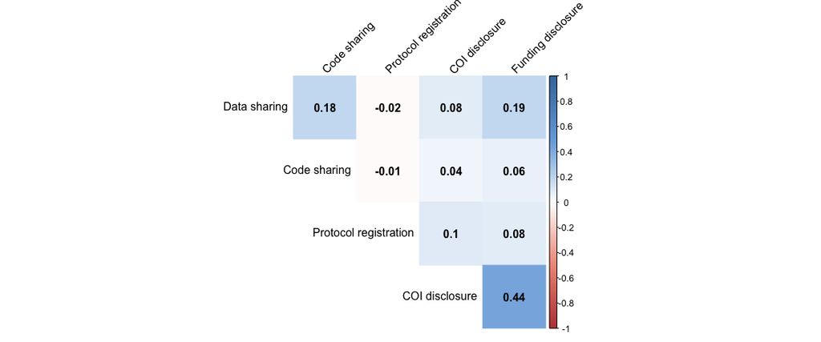

```r
# Create palette
col <- colorRampPalette(c(
  "#BB4444",
  "#EE9988",
  "#FFFFFF",
  "#77AADD",
  "#4477AA"
))

# Plot
pmcoa %>%
  select(!!!indicator_vars) %>%
  rename(!!!indicator_vars_dic) %>%
  cor() %>%
  corrplot(
    method = "color",
    col = col(200),
    type = "upper",
    order = "hclust",
    addCoef.col = "black", # Add coefficient of correlation
    tl.col = "black",
    tl.srt = 45, # Text label color and rotation
    diag = FALSE   # Hide correlation coefficient on the principal diagonal
  )
```

Table for research articles.

```r
pmcoa %>%
  filter(is_art) %>%
  count(!!!indicator_vars, sort = T) %>%
  rename(!!!indicator_vars_dic) %>%
  mutate(N = sum(n)) %>%
  mutate(p = scales::percent(n / N, accuracy = 0.1)) %>%
  sable()
```

| Data sharing | Code sharing | COI disclosure | Funding disclosure | Protocol registration | n | N | p |
| --- | --- | --- | --- | --- | --- | --- | --- |
| FALSE | FALSE | TRUE | TRUE | FALSE | 1135195 | 2285193 | 49.7% |
| FALSE | FALSE | FALSE | FALSE | FALSE | 321626 | 2285193 | 14.1% |
| FALSE | FALSE | TRUE | FALSE | FALSE | 266331 | 2285193 | 11.7% |
| FALSE | FALSE | FALSE | TRUE | FALSE | 248526 | 2285193 | 10.9% |
| TRUE | FALSE | TRUE | TRUE | FALSE | 167826 | 2285193 | 7.3% |
| FALSE | FALSE | TRUE | TRUE | TRUE | 55278 | 2285193 | 2.4% |
| TRUE | FALSE | FALSE | TRUE | FALSE | 37959 | 2285193 | 1.7% |
| TRUE | TRUE | TRUE | TRUE | FALSE | 15461 | 2285193 | 0.7% |
| FALSE | TRUE | TRUE | TRUE | FALSE | 10982 | 2285193 | 0.5% |
| FALSE | FALSE | TRUE | FALSE | TRUE | 5276 | 2285193 | 0.2% |
| TRUE | FALSE | TRUE | FALSE | FALSE | 4792 | 2285193 | 0.2% |
| TRUE | FALSE | FALSE | FALSE | FALSE | 4570 | 2285193 | 0.2% |
| TRUE | FALSE | TRUE | TRUE | TRUE | 3465 | 2285193 | 0.2% |
| FALSE | TRUE | FALSE | TRUE | FALSE | 2208 | 2285193 | 0.1% |
| TRUE | TRUE | FALSE | TRUE | FALSE | 1747 | 2285193 | 0.1% |
| FALSE | FALSE | FALSE | TRUE | TRUE | 1436 | 2285193 | 0.1% |
| FALSE | FALSE | FALSE | FALSE | TRUE | 682 | 2285193 | 0.0% |
| FALSE | TRUE | TRUE | FALSE | FALSE | 650 | 2285193 | 0.0% |
| TRUE | TRUE | TRUE | FALSE | FALSE | 364 | 2285193 | 0.0% |
| FALSE | TRUE | FALSE | FALSE | FALSE | 352 | 2285193 | 0.0% |
| TRUE | TRUE | FALSE | FALSE | FALSE | 121 | 2285193 | 0.0% |
| TRUE | TRUE | TRUE | TRUE | TRUE | 109 | 2285193 | 0.0% |
| TRUE | FALSE | TRUE | FALSE | TRUE | 80 | 2285193 | 0.0% |
| TRUE | FALSE | FALSE | TRUE | TRUE | 64 | 2285193 | 0.0% |
| FALSE | TRUE | TRUE | TRUE | TRUE | 63 | 2285193 | 0.0% |
| TRUE | FALSE | FALSE | FALSE | TRUE | 9 | 2285193 | 0.0% |
| FALSE | TRUE | FALSE | TRUE | TRUE | 7 | 2285193 | 0.0% |
| FALSE | TRUE | TRUE | FALSE | TRUE | 5 | 2285193 | 0.0% |
| TRUE | TRUE | FALSE | TRUE | TRUE | 5 | 2285193 | 0.0% |
| FALSE | TRUE | FALSE | FALSE | TRUE | 2 | 2285193 | 0.0% |
| TRUE | TRUE | TRUE | FALSE | TRUE | 2 | 2285193 | 0.0% |

Plot for all research articles.

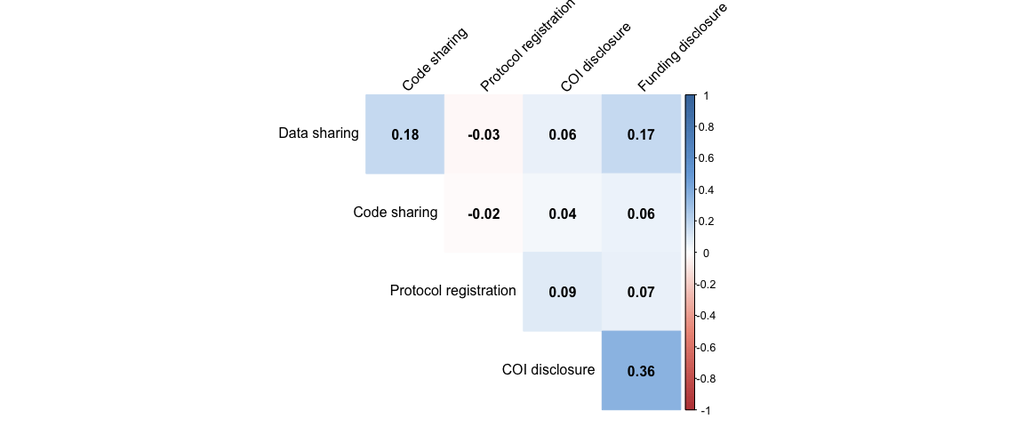

```r
# Create palette
col <- colorRampPalette(c(
  "#BB4444",
  "#EE9988",
  "#FFFFFF",
  "#77AADD",
  "#4477AA"
))

# Plot
pmcoa %>%
  filter(is_art) %>%
  select(!!!indicator_vars) %>%
  rename(!!!indicator_vars_dic) %>%
  cor() %>%
  corrplot(
    method = "color",
    col = col(200),
    type = "upper",
    order = "hclust",
    addCoef.col = "black", # Add coefficient of correlation
    tl.col = "black",
    tl.srt = 45, # Text label color and rotation
    diag = FALSE   # Hide correlation coefficient on the principal diagonal
  )
```

# Meta-data

Number of articles published ≥ 2000.

```r
sprintf("No. published ≥ 2000 = %s", nrow(filter(meta, year >= 2000)))
```

```
[1] "No. published ≥ 2000 = 2428385"
```

All statistics - all articles, 2000 onward.

```r
# Tabulate (this is an expensive operation)
num_table <-
  indicator_vars %>%
  purrr::map_dfr(~ tabulate_nums(meta, .x, c(num_vars, num_vars_meta)))

# Save
write.csv(num_table, "../../output/table_output/indicator-eval_num-table.csv")

# Print
num_table %>%
  sable(full_width = T) %>%
  collapse_rows(columns = 1, valign = "top")
```

| indicator | value | vars | mean | SD | Q1 | Q2 | Q3 | min | max | n_missing | N | p_value |
| --- | --- | --- | --- | --- | --- | --- | --- | --- | --- | --- | --- | --- |
| Data sharing | FALSE | Citation count (OCC) | 15.069 | 57.719 | 2 | 6 | 15 | 1.000 | 15552.00 | 621362 | 2194863 | 0.000 |
|  | TRUE | Citation count (OCC) | 17.820 | 63.196 | 3 | 7 | 16 | 1.000 | 8479.00 | 55097 | 233522 | 0.000 |
|  | FALSE | Eigenfactor (WOS) | 0.298 | 0.565 | 0 | 0 | 0 | 0.000 | 1.71 | 667436 | 2194863 | 0.000 |
|  | TRUE | Eigenfactor (WOS) | 0.709 | 0.754 | 0 | 0 | 2 | 0.000 | 1.71 | 33980 | 233522 | 0.000 |
|  | FALSE | Indicator count | 1.484 | 0.758 | 1 | 2 | 2 | 0.000 | 3.00 | 0 | 2194863 | 0.000 |
|  | TRUE | Indicator count | 1.778 | 0.500 | 2 | 2 | 2 | 0.000 | 3.00 | 0 | 233522 | 0.000 |
|  | FALSE | Journal Impact Factor (WOS) | 3.883 | 3.195 | 2 | 3 | 4 | 0.043 | 70.67 | 667625 | 2194863 | 0.000 |
|  | TRUE | Journal Impact Factor (WOS) | 4.957 | 4.853 | 3 | 3 | 5 | 0.378 | 70.67 | 33991 | 233522 | 0.000 |
|  | FALSE | Number of affiliations | 3.261 | 4.768 | 1 | 3 | 4 | 0.000 | 1710.00 | 0 | 2194863 | 0.000 |
|  | TRUE | Number of affiliations | 4.327 | 5.392 | 2 | 4 | 5 | 0.000 | 619.00 | 0 | 233522 | 0.000 |
|  | FALSE | Number of authors | 6.331 | 30.711 | 3 | 5 | 8 | 0.000 | 3573.00 | 0 | 2194863 | 0.000 |
|  | TRUE | Number of authors | 7.793 | 12.015 | 4 | 6 | 9 | 0.000 | 2854.00 | 0 | 233522 | 0.000 |
|  | FALSE | Number of figures | 3.433 | 3.565 | 1 | 3 | 5 | 0.000 | 305.00 | 0 | 2194863 | 0.000 |
|  | TRUE | Number of figures | 4.884 | 3.434 | 3 | 5 | 7 | 0.000 | 404.00 | 0 | 233522 | 0.000 |
|  | FALSE | Number of references | 38.947 | 34.562 | 19 | 34 | 50 | 0.000 | 3112.00 | 0 | 2194863 | 0.000 |
|  | TRUE | Number of references | 50.579 | 27.975 | 34 | 48 | 64 | 0.000 | 2857.00 | 0 | 233522 | 0.000 |
|  | FALSE | Number of tables | 1.700 | 2.091 | 0 | 1 | 3 | 0.000 | 513.00 | 0 | 2194863 | 0.000 |
|  | TRUE | Number of tables | 1.995 | 2.071 | 0 | 2 | 3 | 0.000 | 102.00 | 0 | 233522 | 0.000 |
|  | FALSE | Year | 2014.883 | 3.648 | 2013 | 2016 | 2018 | 2000.000 | 2020.00 | 0 | 2194863 | 0.000 |
|  | TRUE | Year | 2016.051 | 2.912 | 2015 | 2017 | 2018 | 2000.000 | 2020.00 | 0 | 233522 | 0.000 |
| Code sharing | FALSE | Citation count (OCC) | 15.219 | 54.144 | 2 | 6 | 15 | 1.000 | 15552.00 | 667951 | 2397249 | 0.061 |
|  | TRUE | Citation count (OCC) | 25.318 | 197.650 | 2 | 6 | 15 | 1.000 | 14134.00 | 8508 | 31136 | 0.061 |
|  | FALSE | Eigenfactor (WOS) | 0.344 | 0.604 | 0 | 0 | 0 | 0.000 | 1.71 | 696826 | 2397249 | 0.000 |
|  | TRUE | Eigenfactor (WOS) | 0.457 | 0.622 | 0 | 0 | 1 | 0.000 | 1.71 | 4590 | 31136 | 0.000 |
|  | FALSE | Indicator count | 1.509 | 0.745 | 1 | 2 | 2 | 0.000 | 3.00 | 0 | 2397249 | 0.000 |
|  | TRUE | Indicator count | 1.809 | 0.448 | 2 | 2 | 2 | 0.000 | 3.00 | 0 | 31136 | 0.000 |
|  | FALSE | Journal Impact Factor (WOS) | 3.979 | 3.389 | 2 | 3 | 4 | 0.043 | 70.67 | 697023 | 2397249 | 0.000 |
|  | TRUE | Journal Impact Factor (WOS) | 5.824 | 5.732 | 3 | 4 | 7 | 0.410 | 70.67 | 4593 | 31136 | 0.000 |
|  | FALSE | Number of affiliations | 3.351 | 4.794 | 2 | 3 | 4 | 0.000 | 1710.00 | 0 | 2397249 | 0.000 |
|  | TRUE | Number of affiliations | 4.307 | 7.610 | 2 | 3 | 5 | 0.000 | 446.00 | 0 | 31136 | 0.000 |

[output cut: 70 more lines]

Median and IQR - all articles, 2000 onward.

```r
# Save
prettify_num_table(num_table) %>%
  write.csv("../../output/table_output/indicator-eval_num-table-pretty.csv")

# Print
prettify_num_table(num_table) %>%
  sable(full_width = T) %>%
  collapse_rows(columns = 1, valign = "top")
```

| indicator | vars | Absent | Present | p_value |
| --- | --- | --- | --- | --- |
| Data sharing | Citation count (OCC) | 6 (2-15) | 7 (3-16) | 1.61E-222 |
|  | Eigenfactor (WOS) | 0 (0-0) | 0 (0-2) | 0.00E+00 |
|  | Indicator count | 2 (1-2) | 2 (2-2) | 0.00E+00 |
|  | Journal Impact Factor (WOS) | 3 (2-4) | 3 (3-5) | 0.00E+00 |
|  | Number of affiliations | 3 (1-4) | 4 (2-5) | 0.00E+00 |
|  | Number of authors | 5 (3-8) | 6 (4-9) | 0.00E+00 |
|  | Number of figures | 3 (1-5) | 5 (3-7) | 0.00E+00 |
|  | Number of references | 34 (19-50) | 48 (34-64) | 0.00E+00 |
|  | Number of tables | 1 (0-3) | 2 (0-3) | 0.00E+00 |
|  | Year | 2016 (2013-2018) | 2017 (2015-2018) | 0.00E+00 |
| Code sharing | Citation count (OCC) | 6 (2-15) | 6 (2-15) | 6.08E-02 |
|  | Eigenfactor (WOS) | 0 (0-0) | 0 (0-1) | 0.00E+00 |
|  | Indicator count | 2 (1-2) | 2 (2-2) | 0.00E+00 |
|  | Journal Impact Factor (WOS) | 3 (2-4) | 4 (3-7) | 0.00E+00 |
|  | Number of affiliations | 3 (2-4) | 3 (2-5) | 0.00E+00 |
|  | Number of authors | 5 (3-8) | 5 (3-8) | 1.15E-01 |
|  | Number of figures | 3 (1-5) | 5 (3-7) | 0.00E+00 |
|  | Number of references | 35 (20-51) | 46 (31-64) | 0.00E+00 |
|  | Number of tables | 1 (0-3) | 1 (0-3) | 1.12E-08 |
|  | Year | 2016 (2013-2018) | 2018 (2016-2019) | 0.00E+00 |
| COI disclosure | Citation count (OCC) | 7 (3-18) | 6 (2-14) | 0.00E+00 |
|  | Eigenfactor (WOS) | 0 (0-0) | 0 (0-0) | 0.00E+00 |
|  | Indicator count | 1 (0-1) | 2 (2-2) | 0.00E+00 |
|  | Journal Impact Factor (WOS) | 3 (2-5) | 3 (2-4) | 7.49E-181 |
|  | Number of affiliations | 2 (1-3) | 3 (2-4) | 0.00E+00 |
|  | Number of authors | 4 (3-7) | 5 (4-8) | 0.00E+00 |
|  | Number of figures | 2 (0-5) | 3 (1-6) | 0.00E+00 |
|  | Number of references | 22 (5-42) | 38 (25-54) | 0.00E+00 |
|  | Number of tables | 0 (0-2) | 1 (0-3) | 0.00E+00 |
|  | Year | 2014 (2010-2016) | 2016 (2014-2018) | 0.00E+00 |
| Funding disclosure | Citation count (OCC) | 4 (2-11) | 6 (2-16) | 0.00E+00 |
|  | Eigenfactor (WOS) | 0 (0-0) | 0 (0-1) | 0.00E+00 |
|  | Indicator count | 1 (0-1) | 2 (2-2) | 0.00E+00 |
|  | Journal Impact Factor (WOS) | 3 (2-4) | 3 (3-4) | 0.00E+00 |
|  | Number of affiliations | 2 (1-3) | 3 (2-5) | 0.00E+00 |
|  | Number of authors | 4 (2-6) | 6 (4-8) | 0.00E+00 |
|  | Number of figures | 1 (0-3) | 4 (2-6) | 0.00E+00 |
|  | Number of references | 17 (5-34) | 40 (27-55) | 0.00E+00 |
|  | Number of tables | 0 (0-2) | 1 (0-3) | 0.00E+00 |
|  | Year | 2015 (2012-2017) | 2016 (2013-2018) | 0.00E+00 |
| Protocol registration | Citation count (OCC) | 6 (2-15) | 6 (2-14) | 2.69E-07 |
|  | Eigenfactor (WOS) | 0 (0-0) | 0 (0-0) | 2.37E-06 |
|  | Indicator count | 2 (1-2) | 3 (3-3) | 0.00E+00 |
|  | Journal Impact Factor (WOS) | 3 (2-4) | 3 (2-4) | 0.00E+00 |
|  | Number of affiliations | 3 (2-4) | 4 (3-7) | 0.00E+00 |
|  | Number of authors | 5 (3-8) | 7 (5-11) | 0.00E+00 |
|  | Number of figures | 3 (1-6) | 2 (1-3) | 0.00E+00 |
|  | Number of references | 35 (20-52) | 36 (27-48) | 3.19E-232 |
|  | Number of tables | 1 (0-3) | 3 (1-4) | 0.00E+00 |
|  | Year | 2016 (2013-2018) | 2017 (2015-2018) | 0.00E+00 |

# Year

## All

Table non-missing, since 1990.

```r
pmc %>%
  select(year, !!!indicator_vars) %>%
  filter(year >= 1990) %>%
  add_count(year, name = "N") %>%
  rename(!!!indicator_vars_dic) %>%
  gather(key, value, -year, -N) %>%
  mutate(key = fct_relevel(key, "Data sharing")) %>%
  group_by(key, year, N) %>%
  summarise_at(vars(value), list(n = sum, p = mean)) %>%
  mutate(p = scales::percent(p, accuracy = 0.1)) %>%
  select(indicator = key, Year = year, n, N, p) %>%
  sable()
```

| indicator | Year | n | N | p |
| --- | --- | --- | --- | --- |
| Data sharing | 1990 | 3 | 2715 | 0.1% |
| Data sharing | 1991 | 2 | 2763 | 0.1% |
| Data sharing | 1992 | 2 | 2753 | 0.1% |
| Data sharing | 1993 | 2 | 3177 | 0.1% |
| Data sharing | 1994 | 0 | 3435 | 0.0% |
| Data sharing | 1995 | 0 | 3390 | 0.0% |
| Data sharing | 1996 | 9 | 3621 | 0.2% |
| Data sharing | 1997 | 123 | 3913 | 3.1% |
| Data sharing | 1998 | 127 | 4201 | 3.0% |
| Data sharing | 1999 | 108 | 4490 | 2.4% |
| Data sharing | 2000 | 106 | 4973 | 2.1% |
| Data sharing | 2001 | 113 | 6648 | 1.7% |
| Data sharing | 2002 | 137 | 6993 | 2.0% |
| Data sharing | 2003 | 171 | 8003 | 2.1% |
| Data sharing | 2004 | 259 | 10392 | 2.5% |
| Data sharing | 2005 | 573 | 15337 | 3.7% |
| Data sharing | 2006 | 840 | 19842 | 4.2% |
| Data sharing | 2007 | 1506 | 26997 | 5.6% |
| Data sharing | 2008 | 2217 | 42687 | 5.2% |
| Data sharing | 2009 | 3036 | 57415 | 5.3% |
| Data sharing | 2010 | 4235 | 78863 | 5.4% |
| Data sharing | 2011 | 6095 | 108665 | 5.6% |
| Data sharing | 2012 | 8209 | 145770 | 5.6% |
| Data sharing | 2013 | 12423 | 183192 | 6.8% |
| Data sharing | 2014 | 18020 | 219253 | 8.2% |
| Data sharing | 2015 | 25524 | 247540 | 10.3% |
| Data sharing | 2016 | 29650 | 270425 | 11.0% |
| Data sharing | 2017 | 35082 | 303215 | 11.6% |
| Data sharing | 2018 | 40537 | 334766 | 12.1% |
| Data sharing | 2019 | 46534 | 372874 | 12.5% |

[output cut: 125 more lines]

Plot non-missing, since 1990.

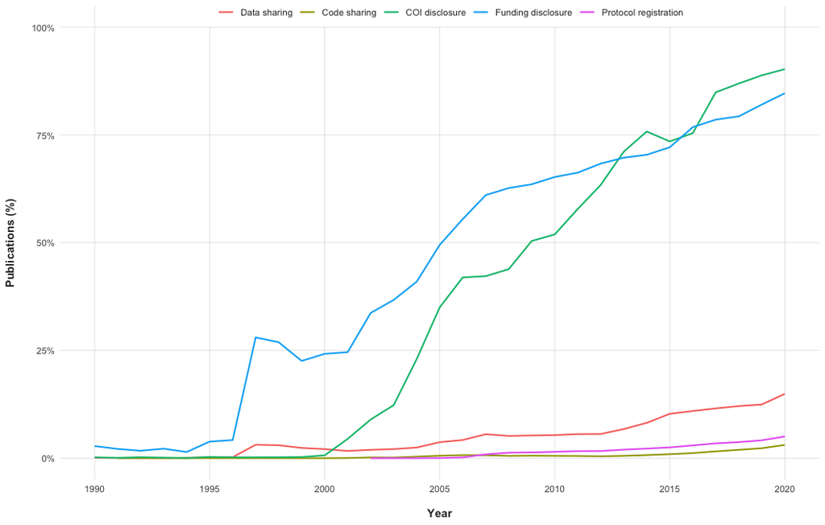

```r
pmc %>%
  select(year, !!!indicator_vars) %>%
  filter(year >= 1990) %>%
  gather("key", "value", -year) %>%
  mutate(key = recode(key, !!!dic)) %>%
  count(year, key, value) %>%
  group_by(year, key) %>%
  mutate(p = n / sum(n)) %>%
  filter(value) %>%
  ungroup() %>%
  mutate(key = fct_relevel(key, "Data sharing")) %>%
  ggplot(aes(x = year, y = p, color = key)) +
  geom_line(size = 0.75) +
  scale_x_continuous(breaks = seq(1990, 2020, 5), limits = c(1990, 2020)) +
  scale_y_continuous(limits = c(0, 1), labels = scales::percent) +
  scale_color_discrete(name = NULL) +
  labs(y = "Publications (%)\n", x = "\nYear") +
  theme(
    panel.grid.minor = element_blank(),
    legend.position = c(0.51, 0.9865),
    legend.direction = "horizontal"
  )
```

```r
ggsave(
  filename = "../../output/figure_output/indicator-eval_indicator-by-year.jpg",
  width = 11,
  height = 7
)
```

## Research

Table non-missing research, since 1990.

```r
pmc %>%
  filter(is_art) %>%
  select(year, !!!indicator_vars) %>%
  filter(year >= 1990) %>%
  add_count(year, name = "N") %>%
  rename(!!!indicator_vars_dic) %>%
  gather(key, value, -year, -N) %>%
  mutate(key = fct_relevel(key, "Data sharing")) %>%
  group_by(key, year, N) %>%
  summarise_at(vars(value), list(n = sum, p = mean)) %>%
  mutate(p = scales::percent(p, accuracy = 0.1)) %>%
  select(indicator = key, Year = year, n, N, p) %>%
  sable()
```

| indicator | Year | n | N | p |
| --- | --- | --- | --- | --- |
| Data sharing | 1990 | 3 | 2172 | 0.1% |
| Data sharing | 1991 | 2 | 2173 | 0.1% |
| Data sharing | 1992 | 2 | 2224 | 0.1% |
| Data sharing | 1993 | 2 | 2496 | 0.1% |
| Data sharing | 1994 | 0 | 2711 | 0.0% |
| Data sharing | 1995 | 0 | 2692 | 0.0% |
| Data sharing | 1996 | 9 | 2922 | 0.3% |
| Data sharing | 1997 | 122 | 2994 | 4.1% |
| Data sharing | 1998 | 127 | 3092 | 4.1% |
| Data sharing | 1999 | 105 | 3136 | 3.3% |
| Data sharing | 2000 | 104 | 3327 | 3.1% |
| Data sharing | 2001 | 111 | 4278 | 2.6% |
| Data sharing | 2002 | 133 | 4692 | 2.8% |
| Data sharing | 2003 | 168 | 5260 | 3.2% |
| Data sharing | 2004 | 250 | 7249 | 3.4% |
| Data sharing | 2005 | 564 | 11283 | 5.0% |
| Data sharing | 2006 | 822 | 15085 | 5.4% |
| Data sharing | 2007 | 1482 | 21611 | 6.9% |
| Data sharing | 2008 | 2192 | 36326 | 6.0% |
| Data sharing | 2009 | 3005 | 49406 | 6.1% |
| Data sharing | 2010 | 4175 | 68019 | 6.1% |
| Data sharing | 2011 | 6032 | 95069 | 6.3% |
| Data sharing | 2012 | 8096 | 127760 | 6.3% |
| Data sharing | 2013 | 12239 | 156576 | 7.8% |
| Data sharing | 2014 | 17695 | 184131 | 9.6% |
| Data sharing | 2015 | 25063 | 207695 | 12.1% |
| Data sharing | 2016 | 29031 | 232555 | 12.5% |
| Data sharing | 2017 | 34333 | 259222 | 13.2% |
| Data sharing | 2018 | 39793 | 285208 | 14.0% |
| Data sharing | 2019 | 45482 | 315689 | 14.4% |

[output cut: 125 more lines]

Plot non-missing research, since 1990.

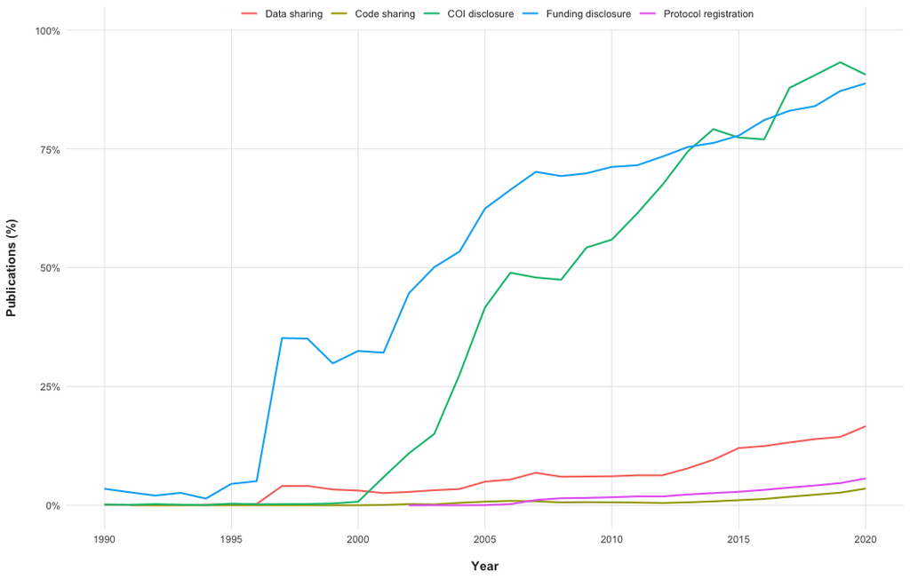

```r
pmc %>%
  select(year, is_art, !!!indicator_vars) %>%
  filter(year > 1989 & is_art) %>%
  gather("key", "value", !!!indicator_vars) %>%
  mutate(key = recode(key, !!!dic)) %>%
  count(year, key, value) %>%
  group_by(year, key) %>%
  mutate(p = n / sum(n)) %>%
  filter(value) %>%
  ungroup() %>%
  mutate(key = fct_relevel(key, "Data sharing")) %>%
  ggplot(aes(x = year, y = p, color = key)) +
  geom_line(size = 0.75) +
  scale_x_continuous(breaks = seq(1990, 2020, 5), limits = c(1990, 2020)) +
  scale_y_continuous(limits = c(0, 1), labels = scales::percent) +
  scale_color_discrete(name = NULL) +
  labs(y = "Publications (%)\n", x = "\nYear") +
  theme(
    panel.grid.minor = element_blank(),
    legend.position = c(0.51, 0.9865),
    legend.direction = "horizontal"
  )
```

```r
ggsave(
  "../../output/figure_output/indicator-eval_indicator-by-year_art.jpg",
  width = 11,
  height = 7
)
```

# Country

## Create cohort

Prepare indicator data.

```r
pmc_country_1990 <-
  pmc %>%
  select(pmcid_pmc, year, affiliation_country, !!!indicator_vars) %>%
  filter(year > 1989) %>%
  drop_na(affiliation_country) %>%
  tidyr::separate_rows(affiliation_country, sep = "; ") %>%
  group_by(pmcid_pmc) %>%
  distinct(affiliation_country, .keep_all = T) %>%
  ungroup() %>%
  add_count(affiliation_country)
```

Prepare coordinate data.

```r
# Get map
world_map <- ggplot2::map_data('world') %>% as_tibble

# Update China to read Hong Kong whenever it refers to Hong Kong
world_map$region[world_map$subregion == "Hong Kong"] <- "Hong Kong"
```

Join.

```r
country_n <-
  pmc_country_1990 %>%
  group_by(affiliation_country, n) %>%
  summarise_at(vars(!!!indicator_vars), mean) %>%
  right_join(world_map, by = c('affiliation_country' = 'region')) %>%
  rename(region = affiliation_country)
```

## Plot

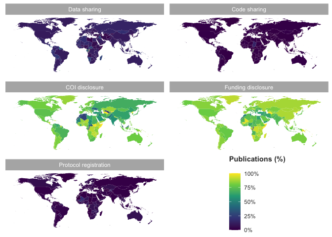

```r
country_n %>%
  filter(region != "Antarctica") %>%
  gather(Indicator, vals, !!!indicator_vars) %>%
  mutate(Indicator = recode(Indicator, !!!dic)) %>%
  mutate(Indicator = fct_relevel(Indicator, "Data sharing")) %>%
  ggplot(aes(x = long, y = lat, group = group)) +
  geom_polygon(aes(fill = vals)) +
  facet_wrap(~ Indicator, scales = "free", nrow = 3) +
  theme(
    text = element_text(color = "grey20"),
    plot.subtitle = element_text(size = 14),
    axis.ticks = element_blank(),
    axis.text.x  = element_blank(),
    axis.text.y  = element_blank(),
    panel.grid = element_blank(),
    panel.background  = element_rect(fill = "white"),
    plot.background   = element_rect(fill = "white"),
    legend.position   = c(0.78, 0.18),
    legend.background = element_blank(),
    legend.key = element_blank()
  ) +
  labs(x = NULL, y = NULL) +
  scale_fill_viridis_c(labels = scales::percent, name = "Publications (%)\n")
```

```r
ggsave(
  "../../output/figure_output/indicator-eval_indicator-by-country.jpg",
  width = 12,
  height = 12
)
```

# Fields of science

## All

Table - since 1990, non-missing.

```r
field_table <-
  pmc %>%
  select(year, field, !!!indicator_vars) %>%
  drop_na(field) %>%
  filter(year >= 1990) %>%
  rename(!!!indicator_vars_dic) %>%
  mutate(field = fct_infreq(field)) %>%
  gather(indicator, value, -year, -field) %>%
  group_by(field, indicator) %>%
  summarise_at(vars(value), list(n = sum, p = mean)) %>%
  mutate(p_text = sprintf("%s (%.1f%%)", n, p * 100)) %>%
  ungroup()

field_table %>%
  sable(full_width = T)
```

| field | indicator | n | p | p_text |
| --- | --- | --- | --- | --- |
| MEDICINE | Code sharing | 10990 | 0.009 | 10990 (0.9%) |
| MEDICINE | COI disclosure | 924502 | 0.794 | 924502 (79.4%) |
| MEDICINE | Data sharing | 81338 | 0.070 | 81338 (7.0%) |
| MEDICINE | Funding disclosure | 829086 | 0.712 | 829086 (71.2%) |
| MEDICINE | Protocol registration | 41029 | 0.035 | 41029 (3.5%) |
| HEALTH | Code sharing | 1456 | 0.005 | 1456 (0.5%) |
| HEALTH | COI disclosure | 240968 | 0.813 | 240968 (81.3%) |
| HEALTH | Data sharing | 10587 | 0.036 | 10587 (3.6%) |
| HEALTH | Funding disclosure | 201450 | 0.680 | 201450 (68.0%) |
| HEALTH | Protocol registration | 17062 | 0.058 | 17062 (5.8%) |
| BIOLOGY | Code sharing | 10125 | 0.039 | 10125 (3.9%) |
| BIOLOGY | COI disclosure | 183235 | 0.705 | 183235 (70.5%) |
| BIOLOGY | Data sharing | 76152 | 0.293 | 76152 (29.3%) |
| BIOLOGY | Funding disclosure | 233847 | 0.900 | 233847 (90.0%) |
| BIOLOGY | Protocol registration | 275 | 0.001 | 275 (0.1%) |
| INF DIS | Code sharing | 3479 | 0.015 | 3479 (1.5%) |
| INF DIS | COI disclosure | 171330 | 0.738 | 171330 (73.8%) |
| INF DIS | Data sharing | 39447 | 0.170 | 39447 (17.0%) |
| INF DIS | Funding disclosure | 199996 | 0.862 | 199996 (86.2%) |
| INF DIS | Protocol registration | 2501 | 0.011 | 2501 (1.1%) |
| BRAIN | Code sharing | 2835 | 0.015 | 2835 (1.5%) |
| BRAIN | COI disclosure | 154760 | 0.809 | 154760 (80.9%) |
| BRAIN | Data sharing | 11882 | 0.062 | 11882 (6.2%) |
| BRAIN | Funding disclosure | 148857 | 0.779 | 148857 (77.9%) |
| BRAIN | Protocol registration | 6285 | 0.033 | 6285 (3.3%) |
| CHEMISTRY | Code sharing | 831 | 0.006 | 831 (0.6%) |
| CHEMISTRY | COI disclosure | 99052 | 0.722 | 99052 (72.2%) |
| CHEMISTRY | Data sharing | 9778 | 0.071 | 9778 (7.1%) |
| CHEMISTRY | Funding disclosure | 117892 | 0.859 | 117892 (85.9%) |
| CHEMISTRY | Protocol registration | 528 | 0.004 | 528 (0.4%) |
| ENGNG | Code sharing | 262 | 0.011 | 262 (1.1%) |
| ENGNG | COI disclosure | 18196 | 0.796 | 18196 (79.6%) |
| ENGNG | Data sharing | 1095 | 0.048 | 1095 (4.8%) |
| ENGNG | Funding disclosure | 19658 | 0.860 | 19658 (86.0%) |
| ENGNG | Protocol registration | 22 | 0.001 | 22 (0.1%) |
| SOC SCI | Code sharing | 348 | 0.021 | 348 (2.1%) |
| SOC SCI | COI disclosure | 12495 | 0.763 | 12495 (76.3%) |
| SOC SCI | Data sharing | 1291 | 0.079 | 1291 (7.9%) |
| SOC SCI | Funding disclosure | 12287 | 0.750 | 12287 (75.0%) |
| SOC SCI | Protocol registration | 541 | 0.033 | 541 (3.3%) |
| COMP SCI | Code sharing | 518 | 0.047 | 518 (4.7%) |
| COMP SCI | COI disclosure | 8942 | 0.803 | 8942 (80.3%) |
| COMP SCI | Data sharing | 743 | 0.067 | 743 (6.7%) |
| COMP SCI | Funding disclosure | 9379 | 0.842 | 9379 (84.2%) |
| COMP SCI | Protocol registration | 48 | 0.004 | 48 (0.4%) |
| PHYS/MATH | Code sharing | 52 | 0.020 | 52 (2.0%) |
| PHYS/MATH | COI disclosure | 1503 | 0.591 | 1503 (59.1%) |
| PHYS/MATH | Data sharing | 181 | 0.071 | 181 (7.1%) |
| PHYS/MATH | Funding disclosure | 2184 | 0.859 | 2184 (85.9%) |
| PHYS/MATH | Protocol registration | 0 | 0.000 | 0 (0.0%) |
| HUMANITIES | Code sharing | 2 | 0.005 | 2 (0.5%) |
| HUMANITIES | COI disclosure | 153 | 0.401 | 153 (40.1%) |
| HUMANITIES | Data sharing | 8 | 0.021 | 8 (2.1%) |
| HUMANITIES | Funding disclosure | 206 | 0.539 | 206 (53.9%) |
| HUMANITIES | Protocol registration | 0 | 0.000 | 0 (0.0%) |
| EARTH | Code sharing | 2 | 0.014 | 2 (1.4%) |
| EARTH | COI disclosure | 41 | 0.283 | 41 (28.3%) |
| EARTH | Data sharing | 7 | 0.048 | 7 (4.8%) |
| EARTH | Funding disclosure | 141 | 0.972 | 141 (97.2%) |
| EARTH | Protocol registration | 0 | 0.000 | 0 (0.0%) |

Plot of all publications since 1990 - unscaled.

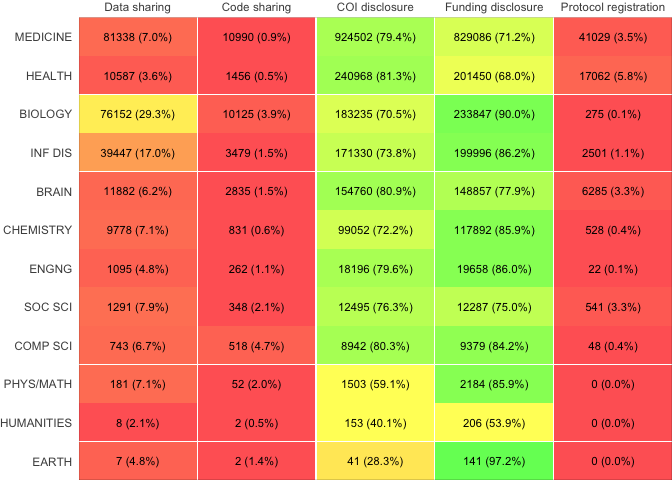

```r
colfunc <- colorRampPalette(c("red", "yellow", "yellow", "green"))

field_table %>%
  mutate(field = fct_rev(field)) %>%
  mutate(indicator = fct_relevel(indicator, "Data sharing")) %>%
  ggplot(aes(x = indicator, y = field, fill = p, label = p_text)) +
  geom_tile(aes(width = 0.99, height = 0.99)) +
  scale_fill_gradientn(colours = alpha(colfunc(10), 0.7)) +
  # scale_fill_continuous(limit=c(50,100), low = "#F8766D", high = "#00BA38") +
  # scale_fill_continuous(limit = c(0, 1), low = "red", high = "lightgreen") +
  # scale_fill_continuous(labels = scales::percent, , name = "Proportion")
  # scale_fill_gradientn(colours = cm.colors(10, alpha = 0.8))
  # scale_fill_gradientn(colours = topo.colors(10, alpha = 0.8))
  # scale_fill_gradientn(colours = terrain.colors(10, alpha = 0.8))
  # scale_fill_viridis_c(option = "cividis")
  # scale_fill_viridis_c()
  # scale_fill_gradientn(colours = heat.colors(10, alpha = 0.8))
  geom_text(size = 3) +
  scale_x_discrete(position = "top", expand = c(0, 0)) +
  scale_y_discrete(expand = c(0, 0)) +
  labs(x = NULL, y = NULL) +
  theme(
    axis.line = element_blank(),
    legend.position = "none",
    panel.background = element_blank(),
    panel.grid.major = element_blank(),
    panel.grid.minor = element_blank(),
    panel.border = element_rect(size = 0.1, fill = NA),
    axis.ticks = element_blank(),
    plot.margin = unit(c(0, 0, 0, 0), "cm")
  )
```

```r
ggsave(
  "../../output/figure_output/indicator-eval_field-by-indicator_unscaled.jpg",
  width = 8,
  height = 6
)
```

Plot of all publications since 1990 - scaled.

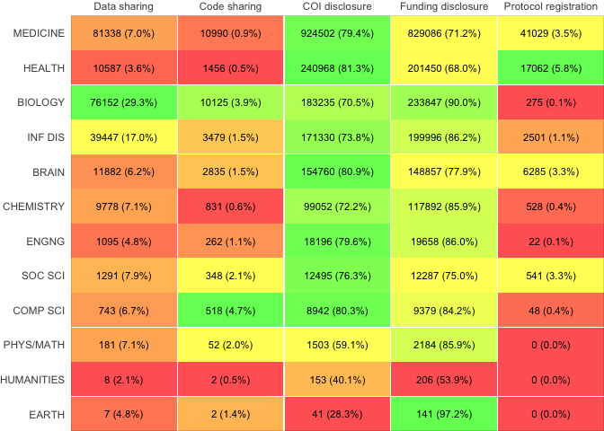

```r
colfunc <- colorRampPalette(c("red", "yellow", "yellow", "green"))

field_table %>%
  mutate(field = fct_rev(field)) %>%
  mutate(indicator = fct_relevel(indicator, "Data sharing")) %>%
  group_by(indicator) %>%
  mutate(p = scales::rescale(p)) %>%
  ggplot(aes(x = indicator, y = field, fill = p, label = p_text)) +
  geom_tile(aes(width = 0.99, height = 0.99)) +
  scale_fill_gradientn(colours = alpha(colfunc(10), 0.7)) +
  # scale_fill_continuous(limit=c(50,100), low = "#F8766D", high = "#00BA38") +
  # scale_fill_continuous(limit = c(0, 1), low = "red", high = "lightgreen") +
  # scale_fill_continuous(labels = scales::percent, , name = "Proportion")
  # scale_fill_gradientn(colours = cm.colors(10, alpha = 0.8))
  # scale_fill_gradientn(colours = topo.colors(10, alpha = 0.8))
  # scale_fill_gradientn(colours = terrain.colors(10, alpha = 0.8))
  # scale_fill_viridis_c(option = "cividis")
  # scale_fill_viridis_c()
  # scale_fill_gradientn(colours = heat.colors(10, alpha = 0.8))
  geom_text(size = 3) +
  scale_x_discrete(position = "top", expand = c(0, 0)) +
  scale_y_discrete(expand = c(0, 0)) +
  labs(x = NULL, y = NULL) +
  theme(
    axis.line = element_blank(),
    legend.position = "none",
    panel.background = element_blank(),
    panel.grid.major = element_blank(),
    panel.grid.minor = element_blank(),
    panel.border = element_rect(size = 0.1, fill = NA),
    axis.ticks = element_blank(),
    plot.margin = unit(c(0, 0, 0, 0), "cm")
  )
```

```r
ggsave(
  "../../output/figure_output/indicator-eval_field-by-indicator_scaled.jpg",
  width = 8,
  height = 6
)
```

## Research

Table - since 1990.

```r
field_table_art <-
  pmc %>%
  select(year, is_art, field, !!!indicator_vars) %>%
  drop_na(field) %>%
  filter(year >= 1990 & is_art) %>%
  rename(!!!indicator_vars_dic) %>%
  mutate(field = fct_infreq(field)) %>%
  gather(indicator, value, -year, -is_art, -field) %>%
  group_by(field, indicator) %>%
  summarise_at(vars(value), list(n = sum, p = mean)) %>%
  mutate(p_text = sprintf("%s (%.1f%%)", n, p * 100)) %>%
  ungroup()

field_table_art %>%
  sable(full_width = T)
```

| field | indicator | n | p | p_text |
| --- | --- | --- | --- | --- |
| MEDICINE | Code sharing | 10721 | 0.011 | 10721 (1.1%) |
| MEDICINE | COI disclosure | 814076 | 0.806 | 814076 (80.6%) |
| MEDICINE | Data sharing | 79725 | 0.079 | 79725 (7.9%) |
| MEDICINE | Funding disclosure | 748590 | 0.741 | 748590 (74.1%) |
| MEDICINE | Protocol registration | 39390 | 0.039 | 39390 (3.9%) |
| HEALTH | Code sharing | 1403 | 0.005 | 1403 (0.5%) |
| HEALTH | COI disclosure | 218745 | 0.827 | 218745 (82.7%) |
| HEALTH | Data sharing | 10188 | 0.039 | 10188 (3.9%) |
| HEALTH | Funding disclosure | 185493 | 0.701 | 185493 (70.1%) |
| HEALTH | Protocol registration | 16069 | 0.061 | 16069 (6.1%) |
| BIOLOGY | Code sharing | 10002 | 0.041 | 10002 (4.1%) |
| BIOLOGY | COI disclosure | 172073 | 0.713 | 172073 (71.3%) |
| BIOLOGY | Data sharing | 75297 | 0.312 | 75297 (31.2%) |
| BIOLOGY | Funding disclosure | 221866 | 0.920 | 221866 (92.0%) |
| BIOLOGY | Protocol registration | 271 | 0.001 | 271 (0.1%) |
| INF DIS | Code sharing | 3407 | 0.016 | 3407 (1.6%) |
| INF DIS | COI disclosure | 157015 | 0.751 | 157015 (75.1%) |
| INF DIS | Data sharing | 38823 | 0.186 | 38823 (18.6%) |
| INF DIS | Funding disclosure | 186157 | 0.890 | 186157 (89.0%) |
| INF DIS | Protocol registration | 2422 | 0.012 | 2422 (1.2%) |
| BRAIN | Code sharing | 2776 | 0.016 | 2776 (1.6%) |
| BRAIN | COI disclosure | 138210 | 0.818 | 138210 (81.8%) |
| BRAIN | Data sharing | 11663 | 0.069 | 11663 (6.9%) |
| BRAIN | Funding disclosure | 135587 | 0.803 | 135587 (80.3%) |
| BRAIN | Protocol registration | 6082 | 0.036 | 6082 (3.6%) |
| CHEMISTRY | Code sharing | 811 | 0.006 | 811 (0.6%) |
| CHEMISTRY | COI disclosure | 90709 | 0.724 | 90709 (72.4%) |
| CHEMISTRY | Data sharing | 9646 | 0.077 | 9646 (7.7%) |
| CHEMISTRY | Funding disclosure | 109854 | 0.876 | 109854 (87.6%) |
| CHEMISTRY | Protocol registration | 519 | 0.004 | 519 (0.4%) |
| ENGNG | Code sharing | 260 | 0.012 | 260 (1.2%) |
| ENGNG | COI disclosure | 17378 | 0.805 | 17378 (80.5%) |
| ENGNG | Data sharing | 1084 | 0.050 | 1084 (5.0%) |
| ENGNG | Funding disclosure | 18900 | 0.875 | 18900 (87.5%) |
| ENGNG | Protocol registration | 20 | 0.001 | 20 (0.1%) |
| SOC SCI | Code sharing | 337 | 0.022 | 337 (2.2%) |
| SOC SCI | COI disclosure | 11600 | 0.772 | 11600 (77.2%) |
| SOC SCI | Data sharing | 1265 | 0.084 | 1265 (8.4%) |
| SOC SCI | Funding disclosure | 11621 | 0.773 | 11621 (77.3%) |
| SOC SCI | Protocol registration | 521 | 0.035 | 521 (3.5%) |
| COMP SCI | Code sharing | 508 | 0.048 | 508 (4.8%) |
| COMP SCI | COI disclosure | 8554 | 0.809 | 8554 (80.9%) |
| COMP SCI | Data sharing | 733 | 0.069 | 733 (6.9%) |
| COMP SCI | Funding disclosure | 9047 | 0.856 | 9047 (85.6%) |
| COMP SCI | Protocol registration | 48 | 0.005 | 48 (0.5%) |
| PHYS/MATH | Code sharing | 52 | 0.022 | 52 (2.2%) |
| PHYS/MATH | COI disclosure | 1428 | 0.599 | 1428 (59.9%) |
| PHYS/MATH | Data sharing | 176 | 0.074 | 176 (7.4%) |
| PHYS/MATH | Funding disclosure | 2076 | 0.871 | 2076 (87.1%) |
| PHYS/MATH | Protocol registration | 0 | 0.000 | 0 (0.0%) |
| HUMANITIES | Code sharing | 2 | 0.008 | 2 (0.8%) |
| HUMANITIES | COI disclosure | 109 | 0.438 | 109 (43.8%) |
| HUMANITIES | Data sharing | 6 | 0.024 | 6 (2.4%) |
| HUMANITIES | Funding disclosure | 137 | 0.550 | 137 (55.0%) |
| HUMANITIES | Protocol registration | 0 | 0.000 | 0 (0.0%) |
| EARTH | Code sharing | 2 | 0.014 | 2 (1.4%) |
| EARTH | COI disclosure | 41 | 0.291 | 41 (29.1%) |
| EARTH | Data sharing | 7 | 0.050 | 7 (5.0%) |
| EARTH | Funding disclosure | 139 | 0.986 | 139 (98.6%) |
| EARTH | Protocol registration | 0 | 0.000 | 0 (0.0%) |

Plot of all publications since 1990 - unscaled.

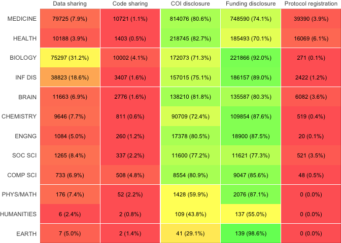

```r
colfunc <- colorRampPalette(c("red", "yellow", "yellow", "green"))

field_table_art %>%
  mutate(field = fct_rev(field)) %>%
  mutate(indicator = fct_relevel(indicator, "Data sharing")) %>%
  ggplot(aes(x = indicator, y = field, fill = p, label = p_text)) +
  geom_tile(aes(width = 0.99, height = 0.99)) +
  scale_fill_gradientn(colours = alpha(colfunc(10), 0.7)) +
  # scale_fill_continuous(limit=c(50,100), low = "#F8766D", high = "#00BA38") +
  # scale_fill_continuous(limit = c(0, 1), low = "red", high = "lightgreen") +
  # scale_fill_continuous(labels = scales::percent, , name = "Proportion")
  # scale_fill_gradientn(colours = cm.colors(10, alpha = 0.8))
  # scale_fill_gradientn(colours = topo.colors(10, alpha = 0.8))
  # scale_fill_gradientn(colours = terrain.colors(10, alpha = 0.8))
  # scale_fill_viridis_c(option = "cividis")
  # scale_fill_viridis_c()
  # scale_fill_gradientn(colours = heat.colors(10, alpha = 0.8))
  geom_text(size = 3) +
  scale_x_discrete(position = "top", expand = c(0, 0)) +
  scale_y_discrete(expand = c(0, 0)) +
  labs(x = NULL, y = NULL) +
  theme(
    axis.line = element_blank(),
    legend.position = "none",
    panel.background = element_blank(),
    panel.grid.major = element_blank(),
    panel.grid.minor = element_blank(),
    panel.border = element_rect(size = 0.1, fill = NA),
    axis.ticks = element_blank(),
    plot.margin = unit(c(0, 0, 0, 0), "cm")
  )
```

```r
ggsave(
  "../../output/figure_output/indicator-eval_field-by-ind_art_unscaled.jpg",
  width = 8,
  height = 6
)
```

Plot of all publications since 1990 - scaled.

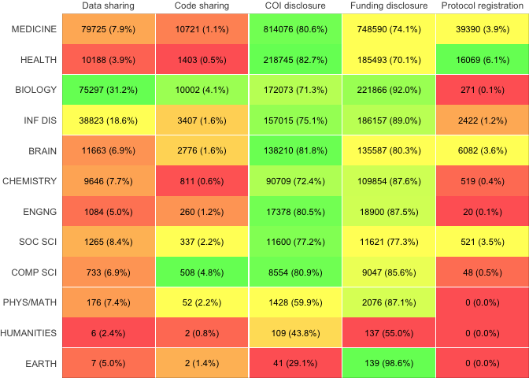

```r
colfunc <- colorRampPalette(c("red", "yellow", "yellow", "green"))

field_table_art %>%
  mutate(field = fct_rev(field)) %>%
  mutate(indicator = fct_relevel(indicator, "Data sharing")) %>%
  group_by(indicator) %>%
  mutate(p = scales::rescale(p)) %>%
  ggplot(aes(x = indicator, y = field, fill = p, label = p_text)) +
  geom_tile(aes(width = 0.99, height = 0.99)) +
  scale_fill_gradientn(colours = alpha(colfunc(10), 0.7)) +
  # scale_fill_continuous(limit=c(50,100), low = "#F8766D", high = "#00BA38") +
  # scale_fill_continuous(limit = c(0, 1), low = "red", high = "lightgreen") +
  # scale_fill_continuous(labels = scales::percent, , name = "Proportion")
  # scale_fill_gradientn(colours = cm.colors(10, alpha = 0.8))
  # scale_fill_gradientn(colours = topo.colors(10, alpha = 0.8))
  # scale_fill_gradientn(colours = terrain.colors(10, alpha = 0.8))
  # scale_fill_viridis_c(option = "cividis")
  # scale_fill_viridis_c()
  # scale_fill_gradientn(colours = heat.colors(10, alpha = 0.8))
  geom_text(size = 3) +
  scale_x_discrete(position = "top", expand = c(0, 0)) +
  scale_y_discrete(expand = c(0, 0)) +
  labs(x = NULL, y = NULL) +
  theme(
    axis.line = element_blank(),
    legend.position = "none",
    panel.background = element_blank(),
    panel.grid.major = element_blank(),
    panel.grid.minor = element_blank(),
    panel.border = element_rect(size = 0.1, fill = NA),
    axis.ticks = element_blank(),
    plot.margin = unit(c(0, 0, 0, 0), "cm")
  )
```

```r
ggsave(
  "../../output/figure_output/indicator-eval_field-by-ind_art_scaled.jpg",
  width = 8,
  height = 6
)
```

## Ranking

Protocol sharing in HEALTH vs. others.

```r
pmc %>%
  drop_na(field) %>%
  select(field, is_register_pred) %>%
  group_by(is_health = field == "HEALTH") %>%
  summarise_at(vars(is_register_pred), list(n = sum, p = mean)) %>%
  mutate(p = scales::percent(p, accuracy = 0.1)) %>%
  sable()
```

| is_health | n | p |
| --- | --- | --- |
| FALSE | 51408 | 2.5% |
| TRUE | 17095 | 5.7% |

P-values.

```r
pmc %>%
  drop_na(field) %>%
  select(field, is_coi_pred) %>%
  mutate(is_health = field == "HEALTH") %$%
  prop.test(table(is_health, is_coi_pred)) %>%
  tidy() %>%
  sable()
```

| estimate1 | estimate2 | statistic | p.value | parameter | conf.low | conf.high | method | alternative |
| --- | --- | --- | --- | --- | --- | --- | --- | --- |
| 0.226 | 0.186 | 2491 | 0 | 1 | 0.039 | 0.042 | 2-sample test for equality of proportions with continuity correction | two.sided |

```r
pmc %>%
  drop_na(field) %>%
  select(field, is_register_pred) %>%
  mutate(is_health = field == "HEALTH") %$%
  prop.test(table(is_health, is_register_pred)) %>%
  tidy() %>%
  sable()
```

| estimate1 | estimate2 | statistic | p.value | parameter | conf.low | conf.high | method | alternative |
| --- | --- | --- | --- | --- | --- | --- | --- | --- |
| 0.975 | 0.943 | 9537 | 0 | 1 | 0.031 | 0.033 | 2-sample test for equality of proportions with continuity correction | two.sided |

Coefficient of variation.

```r
pmc %>%
  select(year, field, !!!indicator_vars) %>%
  drop_na(field) %>%
  filter(year >= 1990) %>%
  rename(!!!indicator_vars_dic) %>%
  mutate(field = fct_infreq(field)) %>%
  gather(indicator, value, -year, -field) %>%
  group_by(field, indicator) %>%
  summarise_at(vars(value), list(p = mean)) %>%
  group_by(indicator) %>%
  summarise_at(vars(p), list(coef_of_variation = ~ sd(.) / mean(.) * 100)) %>%
  sable()
```

| indicator | coef_of_variation |
| --- | --- |
| Code sharing | 75.7 |
| COI disclosure | 25.4 |
| Data sharing | 86.5 |
| Funding disclosure | 14.5 |
| Protocol registration | 130.3 |

## Representative titles

Identify the titles of 15 random articles from each field.

```r
# Set seed
set.seed(1425)

# Create table
field_titles <-
  meta %>%
  select(field, title, journal, n_cite) %>%
  drop_na(field, n_cite) %>%
  group_by(field) %>%
  sample_n(15) %>%
  arrange(field, -n_cite) %>%
  rename(
    Field = field, Title = title, Journal = journal, Citations = n_cite
  )

# Save
field_titles %>%
  write.csv("../../data/interim_data/indicator-eval_field-titles.csv")
```

Select the 3 most representative titles from each field.

```r
# Import selections
field_titles <- read_excel(
  "../../data/interim_data/indicator-eval_field-titles_complete.xlsx"
)

# Create table
field_titles <-
  field_titles %>%
  filter(is_eligible) %>%
  select(Field:Journal)

# Save
field_titles %>%
  write_csv("../../output/table_output/indicator-eval_field-titles.csv")

# Print
field_titles %>%
  sable(full_width = T) %>%
  collapse_rows(columns = 1, valign = "top")
```

| Field | Title | Journal |
| --- | --- | --- |
| BIOLOGY | RHON1 is a novel ribonucleic acid-binding protein that supports RNase E function in the Arabidopsis chloroplast | Nucleic Acids Research |
|  | A new framework for identifying cis-regulatory motifs in prokaryotes | Nucleic Acids Research |
|  | A Switch from a Gradient to a Threshold Mode in the Regulation of a Transcriptional Cascade Promotes Robust Execution of Meiosis in Budding Yeast | PLoS ONE |
| BRAIN | Increased glutamate levels observed upon functional activation in the anterior cingulate cortex using the Stroop Task and functional spectroscopy | Neuroreport |
|  | Alterations of protein composition along the rostro-caudal axis after spinal cord injury: proteomic, in vitro and in vivo analyses | Frontiers in Cellular Neuroscience |
|  | SCN8A mutation in a child presenting with seizures and developmental delays | Cold Spring Harbor Molecular Case Studies |
| CHEMISTRY | Identification and quantification of anthocyanin pigments in colored rice | Nutrition Research and Practice |
|  | Proteomic and metabolomic analyses provide insight into production of volatile and non-volatile flavor components in mandarin hybrid fruit | BMC Plant Biology |
|  | A New Fluorescence Turn-On Probe for Aluminum(III) with High Selectivity and Sensitivity, and its Application to Bioimaging | ChemistryOpen |
| COMP SCI | Response of Retinal Blood Flow to Systemic Hyperoxia as Measured with Dual-Beam Bidirectional Doppler Fourier-Domain Optical Coherence Tomography | PLoS ONE |
|  | Multimodal snapshot spectral imaging for oral cancer diagnostics: a pilot study | Biomedical Optics Express |
|  | 3D Kidney Segmentation from Abdominal Images Using Spatial-Appearance Models | Computational and Mathematical Methods in Medicine |
| EARTH | Analytic expressions for ULF wave radiation belt radial diffusion coefficients | Journal of Geophysical Research. Space Physics |
|  | How Accurately Can We Measure the Reconnection Rate E M for the MMS Diffusion Region Event of 11 July 2017? | Journal of Geophysical Research. Space Physics |
|  | Ion temperature anisotropy across a magnetotail reconnection jet | Geophysical Research Letters |
| ENGNG | Fabrication and Structural Design of Micro Pressure Sensors for Tire Pressure Measurement Systems (TPMS) | Sensors (Basel, Switzerland) |
|  | A Robust Crowdsourcing-Based Indoor Localization System | Sensors (Basel, Switzerland) |
|  | Passband switchable microwave photonic multiband filter | Scientific Reports |
| HEALTH | Music reduces pain and increases functional mobility in fibromyalgia | Frontiers in Psychology |
|  | Complementary and Alternative Medicine on Wikipedia: Opportunities for Improvement | Evidence-based Complementary and Alternative Medicine : eCAM |
|  | The associations between adult body composition and abdominal adiposity outcomes, and relative weight gain and linear growth from birth to age 22 in the Birth to Twenty Plus cohort, South Africa | PLoS ONE |
| HUMANITIES | Trees and networks before and after Darwin | Biology Direct |
|  | The importance of metagenomic surveys to microbial ecology: or why Darwin would have been a metagenomic scientist | Microbial Informatics and Experimentation |
|  | Policing Epistemic Deviance: Albert von Schrenck-Notzing and Albert Moll | Medical History |
| INF DIS | Co-evolution of a broadly neutralizing HIV-1 antibody and founder virus | Nature |
|  | SERINC3 and SERINC5 restrict HIV-1 infectivity and are counteracted by Nef | Nature |
|  | Rapid host switching in generalist Campylobacter strains erodes the signal for tracing human infections | The ISME Journal |
| MEDICINE | Elucidation of Xenobiotic Metabolism Pathways in Human Skin and Human Skin Models by Proteomic Profiling | PLoS ONE |
|  | Implications of Green Tea and Its Constituents in the Prevention of Cancer via the Modulation of Cell Signalling Pathway | BioMed Research International |
|  | Exploring the role of MKK7 in excitotoxicity and cerebral ischemia: a novel pharmacological strategy against brain injury | Cell Death & Disease |
| PHYS/MATH | Laser chimeras as a paradigm for multistable patterns in complex systems | Nature Communications |
|  | Surface tension of Nanofluid-type fuels containing suspended nanomaterials | Nanoscale Research Letters |
|  | ShadowOui: a new visual environment for X-ray optics and synchrotron beamline simulations | Journal of Synchrotron Radiation |
| SOC SCI | An examination of the initial cancer consultation of medical and radiation oncologists using the Cancode interaction analysis system | British Journal of Cancer |
|  | Identical genetic influences underpin behavior problems in adolescence and basic traits of personality | Journal of Child Psychology and Psychiatry, and Allied Disciplines |
|  | Etiological Influences on Perceptions of Parenting: A Longitudinal, Multi-Informant Twin Study | Journal of Youth and Adolescence |

## Representative text

The extracted text for the most cited article with a positive indicator. Using replace = T because certain categories have less than 10 articles with specific indicators. The data were arranged in citation descending order and the best example in terms of (a) a correct prediction, (b) a short text and (c) as high citation as possible was chosen.

```r
# Set seed
set.seed(1515)

# Create table
field_text <-
  pmc %>%
  select(field, ends_with("_text"), pmcid_pmc, n_cite) %>%
  pivot_longer(ends_with("_text"), "indicator") %>%
  drop_na(field, value) %>%
  group_by(field, indicator) %>%
  sample_n(10,  replace = T) %>%
  ungroup() %>%
  arrange(field, indicator, -n_cite) %>%
  select(-n_cite, -pmcid_pmc, pmcid_pmc, n_cite) %>%
  mutate(indicator = recode(indicator, !!! indicator_text_vars_dic))

# Save
field_text %>%
  write.csv("../../data/interim_data/indicator-eval_field-text.csv")
```

```r
# Import selections
field_text <-
  read_excel("../../data/interim_data/indicator-eval_field-text_complete.xlsx")

# Create table
field_text <-
  field_text %>%
  filter(is_eligible) %>%
  select(field:value) %>%
  pivot_wider(names_from = "indicator", values_from = "value")

# Save
field_text %>%
  write_csv("../../output/table_output/indicator-eval_field-text.csv")

# Print
field_text %>% sable(full_width = T)
```

| field | Code sharing | COI disclosure | Data sharing | Funding disclosure | Protocol registration |
| --- | --- | --- | --- | --- | --- |
| BIOLOGY | software used in this manuscript is freely available at https://github com/smith-chem-wisc/gptmd .; the software program morpheus (revision 149) (freely available at http://cwenger github io/morpheus/… | Competing interests The authors declare that they have no competing interests. | the sequencing data of the five degradome libraries are available under ncbi-geo [ ] series accession no gse34433. | This paper was supported by CNPq, CNPq/INCT-Doen√ßas Tropicais, FAPEMIG, CAPES/PROCAD, and CAPES. | In August 2013 a protocol was registered with the Prospero database (registration number CRD42013005307). The characteristics of the studies (PECO, see below) to be included in the review were defined… |
| BRAIN | matlab scripts used in this analysis are available at: https://github com/vsevans/cest . | Competing Interests: The authors have declared that no competing interests exist. | this data is available for download at the dbgap database (phs000092 v1 p1). | Funding: This research received no specific grant from any funding agency in the public, commercial or not-for-profit sectors. | Trial registration This trial was registered with ClinicalTrials.gov, number NCT01716481. |
| CHEMISTRY | acknowledgments code data and user documentation for rte+rrtmgp are available online ( https://github com/robertpincus/rte-rrtmgp ); this manuscript was produced with data and code archived at doi:10 … | The authors declare no competing financial interests. | the data set is deposited in the gene expression omnibus (geo) database [ ] under accession no gse6997. | Funding. This study was supported in part by the National Natural Science Foundation of China (31470407), the Hangzhou Scientific and Technological Program (20150932H04, 20150932H03), and the Zhejiang… | Trial Registration ClinicalTrials.gov NCT01095848 |
| COMP SCI | bash and python scripts used to create the nfbs repository and produce the results and figures in this paper are available on github at: https://github com/preprocessed-connectomes-project/nfb_skullst… | Conflict of Interest Statement The authors declare that the research was conducted in the absence of any commercial or financial relationships that could be construed as a potential conflict of intere… | availability of data and materials the datasets supporting the conclusions of the article are available in the dataverse repository [ http://hdl handle net/10864/11530 ].availability of data and mater… | The authors are grateful to Universiti Kebangsaan Malaysia for supporting this research financially under Grants DIP-2012-03 and 06-01-02-SF1060. | Trial registration The following systematic review was registered in PROSPERO with RN: CRD42019120058. |
| EARTH | the vpic code is a general-purpose pic simulation and available online ( https://github com/lanl/vpic ). | Competing interests The authors declare no competing financial interests. | our database ( supplementary data 1 ) consists of ~11500 5-min samples covering ~960 h dwell time at the mp. | Work at ICL was funded by STFC (UK) grant ST/N000692/1. The authors also acknowledge the support of the International Space Science Institute, Bern, Switzerland. For MMS data visit https://lasp.colora… |  |
| ENGNG | our code is available at: https://github com/raharjaliu/microtrench-chemotherapeutic-vision . | Competing interests: The authors declare that they have no competing interests. | s1 file (xlsxdata availability section and the s4 file 10 1371/journal pone 0221363 | The authors would like to thank the Alsace Region and the French-German Research Institute of Saint-Louis for funding this work. | Trial Registration Current Controlled Trials ISRCTN91381117 |
| HEALTH | python code and associated search keywords are publicly available on a repository (see https://github com/anujamajmundar/vapinglocations ). | Conflicts of Interest: None declared. | raw data is attached to this article. table 1 | Funding This project is supported by General Research Fund of the Research Grants Council of Hong Kong (HKU 769408 M). | Systematic review registration PROSPERO 2015: CRD42015017327 |
| HUMANITIES | the source code was highly valuable-arguably more so than the software itself-because access to the code made it possible to modify it reproduce it and develop it at will.; accordingly the pi made the… | The authors declare they have no competing financial interests. | supplemental material available at figshare: https://doi org/10 25386/genetics6304502 . | Funding: The author received no specific funding for this article. |  |
| INF DIS | code for these simulations is available at https://github com/braindynamicsusyd/spikenet . | Competing interests The authors declare that they have no competing interests. | sequence data that support the findings of this study have been deposited in genbank with the accession codes mf942137-mf942331. | Funding. This work was supported by National Institutes of Health Grant CA 19014 (to NR-T). | Trial Registration ClinicalTrials.gov NCT00295581 |
| MEDICINE | custom analysis and heatmap generation code is available from https://github com/petercombs/eisenlab-code . | The authors declare no competing financial interests. | availability of data and materials all data are available from the geo accession numbers gse39040 gse28425 gse36004 and cse79181 and array express accession number e-mtab-1136.availability of data and… | Funding Not applicable. | Trial registration ClinicalTrials.gov ID NCT00371540 |
| PHYS/MATH | it is opensource and freely available on github [ ].; a code snippet showing the implementation of a three-dimensional median filter is available from the savu github site [ ]. | Competing interests The authors declare that they have no competing interests. | data and materials availability: all data needed to evaluate the conclusions in the paper have been made publicly available in open access through the following dois: 10 5281/zenodo 3238621 and 10 528… | This study was supported by L’Agence Nationale de la Recherche (ANR); reference: ANR-09-BLAN-0093-03. |  |
| SOC SCI | we include r code for step-by-step instructions for our analysis in the supplemental material for those interested in using statnet for analyses. | Competing interests: The authors declare that they have no competing interest. | data availability the data are available through dryad at the following link: https://doi org/10 5061/dryad 53t31 .; data availability the data are available through dryad at the following link: https… | Funding The research reported was not externally funded. | Trial registration Australian New Zealand Clinical Trials Registry ACTRN12611000438954 |

## Galaxies

Number of articles between 2015-2019.

```r
pmcoa %>%
  drop_na(pmid) %>%
  filter(year >= 2015 & year <= 2019) %>%
  nrow()
```

```
[1] 1490270
```

Number of articles per indicator.

```r
pmcoa %>%
  drop_na(pmid) %>%
  filter(year >= 2015 & year <= 2019) %>%
  select(!!! indicator_vars) %>%
  rename(!!! indicator_vars_dic) %>%
  summarise_all(sum) %>%
  gather(Indicator, n) %>%
  sable()
```

| Indicator | n |
| --- | --- |
| Data sharing | 177175 |
| Code sharing | 25650 |
| COI disclosure | 1263147 |
| Funding disclosure | 1192496 |
| Protocol registration | 52798 |

# Journals

## All

Table - since 1990, ≥100 publications.

```r
indicator_by_journal <-
  pmc %>%
  select(year, journal, !!!indicator_vars) %>%
  filter(year >= 1990) %>%
  add_count(journal, name = "n_publications") %>%
  filter(n_publications > 100) %>%
  rename(!!!indicator_vars_dic) %>%
  gather(indicator, value, -year, -journal, -n_publications) %>%
  group_by(journal, indicator) %>%
  summarise_at(vars(value), list(n = sum, p = mean))

indicator_by_journal %>%
  group_by(indicator) %>%
  summarise_at(vars(p), list(
    above_100 = ~ sum_prop(., 1),
    above_90 = ~ sum_prop(., 0.9),
    above_75 = ~ sum_prop(., 0.75),
    above_70 = ~ sum_prop(., 0.7),
    above_50 = ~ sum_prop(., 0.5),
    above_25 = ~ sum_prop(., 0.25),
    above_10 = ~ sum_prop(., 0.10),
    at_0 = ~ sum_prop(., 0, at = T),
    above_0 = ~ sum_prop(., 0)
  )) %>%
  gather(key, value, -indicator) %>%
  pivot_wider(names_from = indicator, values_from = value) %>%
  sable(full_width = T)
```

| key | Code sharing | COI disclosure | Data sharing | Funding disclosure | Protocol registration |
| --- | --- | --- | --- | --- | --- |
| above_100 | 0 (0.0%) | 45 (1.8%) | 1 (0.0%) | 10 (0.4%) | 0 (0.0%) |
| above_90 | 0 (0.0%) | 1033 (41.7%) | 3 (0.1%) | 531 (21.4%) | 0 (0.0%) |
| above_75 | 0 (0.0%) | 1494 (60.3%) | 9 (0.4%) | 1193 (48.2%) | 0 (0.0%) |
| above_70 | 0 (0.0%) | 1584 (63.9%) | 12 (0.5%) | 1331 (53.7%) | 1 (0.0%) |
| above_50 | 0 (0.0%) | 1922 (77.6%) | 34 (1.4%) | 1778 (71.8%) | 3 (0.1%) |
| above_25 | 9 (0.4%) | 2185 (88.2%) | 142 (5.7%) | 2186 (88.3%) | 21 (0.8%) |
| above_10 | 51 (2.1%) | 2321 (93.7%) | 342 (13.8%) | 2388 (96.4%) | 170 (6.9%) |
| at_0 | 1508 (60.9%) | 15 (0.6%) | 519 (21.0%) | 8 (0.3%) | 724 (29.2%) |
| above_0 | 2477 (100.0%) | 2477 (100.0%) | 2477 (100.0%) | 2477 (100.0%) | 2477 (100.0%) |

Plot.

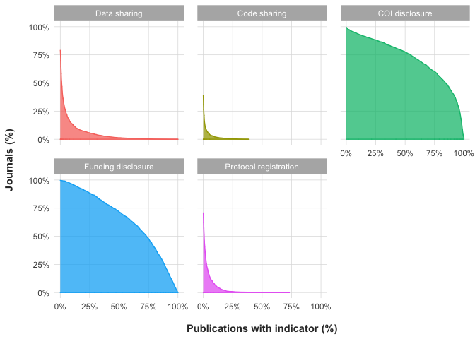

```r
indicator_by_journal %>%
  mutate(indicator = fct_relevel(indicator, "Data sharing")) %>%
  ggplot(aes(x = p, color = indicator, fill = indicator)) +
  stat_ecdf(aes(y = 1 - ..y..), geom = "area", alpha = 0.75, pad = F) +
  scale_y_continuous(
    labels = scales::percent,
    limits = c(0, 1),
    name = "Journals (%)\n"
  ) +
  scale_x_continuous(
    labels = scales::percent,
    name = "\nPublications with indicator (%)"
  ) +
  facet_wrap(~ indicator) +
  theme(
    legend.position = "none",
    panel.grid.minor = element_blank(),
    panel.spacing = unit(1, "lines")
  )
```

```r
ggsave(
  "../../output/figure_output/indicator-eval_indicator-by-journal.jpg",
  width = 10,
  height = 6
)
```

## Research

Table - since 1990, ≥100 publications.

```r
indicator_by_journal_art <-
  pmc %>%
  select(year, is_art, journal, !!!indicator_vars) %>%
  filter(year >= 1990 & is_art) %>%
  add_count(journal, name = "n_publications") %>%
  filter(n_publications > 100) %>%
  rename(!!!indicator_vars_dic) %>%
  gather(indicator, value, -year, -journal, -is_art, -n_publications) %>%
  group_by(journal, indicator) %>%
  summarise_at(vars(value), list(n = sum, p = mean))

indicator_by_journal_art %>%
  group_by(indicator) %>%
  summarise_at(vars(p), list(
    above_100 = ~ sum_prop(., 1),
    above_90 = ~ sum_prop(., 0.9),
    above_75 = ~ sum_prop(., 0.75),
    above_70 = ~ sum_prop(., 0.7),
    above_50 = ~ sum_prop(., 0.5),
    above_25 = ~ sum_prop(., 0.25),
    above_10 = ~ sum_prop(., 0.10),
    at_0 = ~ sum_prop(., 0, at = T),
    above_0 = ~ sum_prop(., 0)
  )) %>%
  gather(key, value, -indicator) %>%
  pivot_wider(names_from = indicator, values_from = value) %>%
  sable(full_width = T)
```

| key | Code sharing | COI disclosure | Data sharing | Funding disclosure | Protocol registration |
| --- | --- | --- | --- | --- | --- |
| above_100 | 0 (0.0%) | 188 (8.3%) | 1 (0.0%) | 52 (2.3%) | 0 (0.0%) |
| above_90 | 0 (0.0%) | 1087 (48.1%) | 3 (0.1%) | 665 (29.4%) | 0 (0.0%) |
| above_75 | 0 (0.0%) | 1440 (63.7%) | 12 (0.5%) | 1210 (53.5%) | 1 (0.0%) |
| above_70 | 0 (0.0%) | 1511 (66.8%) | 16 (0.7%) | 1327 (58.7%) | 3 (0.1%) |
| above_50 | 0 (0.0%) | 1780 (78.7%) | 34 (1.5%) | 1700 (75.2%) | 4 (0.2%) |
| above_25 | 10 (0.4%) | 2009 (88.9%) | 155 (6.9%) | 2030 (89.8%) | 28 (1.2%) |
| above_10 | 51 (2.3%) | 2123 (93.9%) | 348 (15.4%) | 2189 (96.8%) | 194 (8.6%) |
| at_0 | 1365 (60.4%) | 13 (0.6%) | 473 (20.9%) | 5 (0.2%) | 645 (28.5%) |
| above_0 | 2261 (100.0%) | 2261 (100.0%) | 2261 (100.0%) | 2261 (100.0%) | 2261 (100.0%) |

Plot.

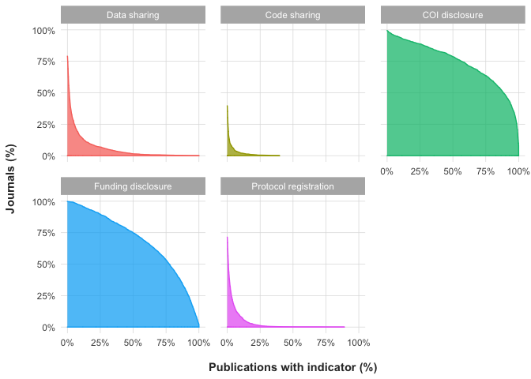

```r
indicator_by_journal_art %>%
  mutate(indicator = fct_relevel(indicator, "Data sharing")) %>%
  ggplot(aes(x = p, color = indicator, fill = indicator)) +
  stat_ecdf(aes(y = 1 - ..y..), geom = "area", alpha = 0.75, pad = F) +
  scale_y_continuous(
    labels = scales::percent,
    limits = c(0, 1),
    name = "Journals (%)\n"
  ) +
  scale_x_continuous(
    labels = scales::percent,
    name = "\nPublications with indicator (%)"
  ) +
  facet_wrap(~ indicator) +
  theme(
    legend.position = "none",
    panel.grid.minor = element_blank(),
    panel.spacing = unit(1, "lines")
  )
```

```r
ggsave(
  "../../output/figure_output/indicator-eval_indicator-by-journal_art.jpg",
  width = 10,
  height = 6
)
```

## Ranking

Data - research articles, since 1990, ≥100 publications.

```r
pmc %>%
  filter(year >= 1990 & is_art) %>%
  add_count(journal) %>%
  mutate(N = n) %>%
  group_by(journal, N) %>%
  summarise_at(vars(is_data_pred), list(n = sum, p = mean)) %>%
  select(journal, n, N, p) %>%
  filter(N > 99) %>%
  arrange(desc(p), desc(n)) %>%
  mutate(p = scales::percent(p, accuracy = 0.1)) %>%
  head(20) %>%
  sable(full_width = T)
```

| journal | n | N | p |
| --- | --- | --- | --- |
| Data in Brief | 4998 | 4998 | 100.0% |
| Microbiology Resource Announcements | 1408 | 1529 | 92.1% |
| Genome Announcements | 6085 | 6649 | 91.5% |
| Molecular Ecology | 190 | 215 | 88.4% |
| GigaScience | 518 | 592 | 87.5% |
| Microbial Genomics | 220 | 258 | 85.3% |
| Microbiome | 577 | 701 | 82.3% |
| Genomics Data | 579 | 710 | 81.5% |
| Cold Spring Harbor Molecular Case Studies | 185 | 229 | 80.8% |
| Royal Society Open Science | 2362 | 3033 | 77.9% |
| Evolution Letters | 92 | 121 | 76.0% |
| Scientific Data | 811 | 1078 | 75.2% |
| Communications Biology | 529 | 714 | 74.1% |
| Systematic Biology | 109 | 152 | 71.7% |
| mSystems | 363 | 511 | 71.0% |
| Structure(London, England:1993) | 142 | 202 | 70.3% |
| Heredity | 97 | 154 | 63.0% |
| Evolution; International Journal of Organic Evolution | 112 | 178 | 62.9% |
| Cell | 231 | 370 | 62.4% |
| Molecular Cell | 244 | 397 | 61.5% |

Code - research articles.

```r
pmc %>%
  filter(year >= 1990 & is_art) %>%
  add_count(journal) %>%
  mutate(N = n) %>%
  group_by(journal, N) %>%
  summarise_at(vars(is_code_pred), list(n = sum, p = mean)) %>%
  select(journal, n, N, p) %>%
  filter(N > 99) %>%
  arrange(desc(p), desc(n)) %>%
  mutate(p = scales::percent(p, accuracy = 0.1)) %>%
  head(20) %>%
  sable(full_width = T)
```

| journal | n | N | p |
| --- | --- | --- | --- |
| GigaScience | 235 | 592 | 39.7% |
| Bioinformatics | 1221 | 3109 | 39.3% |
| Frontiers in Neuroinformatics | 203 | 595 | 34.1% |
| NPJ Systems Biology and Applications | 45 | 137 | 32.8% |
| Source Code for Biology and Medicine | 55 | 168 | 32.7% |
| Scientific Data | 342 | 1078 | 31.7% |
| Systematic Biology | 48 | 152 | 31.6% |
| Microbial Genomics | 79 | 258 | 30.6% |
| Journal of Cheminformatics | 164 | 569 | 28.8% |
| Behavior Research Methods | 47 | 174 | 27.0% |
| Network Neuroscience | 26 | 100 | 26.0% |
| Algorithms for Molecular Biology : AMB | 74 | 316 | 23.4% |
| Journal of Biomedical Semantics | 97 | 419 | 23.2% |
| Nature methods | 144 | 636 | 22.6% |
| NPJ Digital Medicine | 33 | 146 | 22.6% |
| Briefings in Bioinformatics | 35 | 157 | 22.3% |
| BMC Bioinformatics | 2048 | 9307 | 22.0% |
| mSystems | 108 | 511 | 21.1% |
| Virus Evolution | 48 | 232 | 20.7% |
| Microbiome | 142 | 701 | 20.3% |

COI - any publication.

```r
pmc %>%
  filter(year >= 1990) %>%
  add_count(journal) %>%
  mutate(N = n) %>%
  group_by(journal, N) %>%
  summarise_at(vars(is_coi_pred), list(n = sum, p = mean)) %>%
  select(journal, n, N, p) %>%
  filter(N > 99) %>%
  arrange(desc(p), desc(n)) %>%
  mutate(p = scales::percent(p, accuracy = 0.1)) %>%
  head(20) %>%
  sable(full_width = T)
```

| journal | n | N | p |
| --- | --- | --- | --- |
| Proceedings of the National Academy of Sciences of the United States of America | 2907 | 2907 | 100.0% |
| World Journal of Clinical Cases | 793 | 793 | 100.0% |
| Haematologica | 666 | 666 | 100.0% |
| Neurology | 505 | 505 | 100.0% |
| Endocrinology, Diabetes & Metabolism Case Reports | 483 | 483 | 100.0% |
| International Journal of Health Policy and Management | 444 | 444 | 100.0% |
| Wellcome Open Research | 435 | 435 | 100.0% |
| Clinical Practice and Cases in Emergency Medicine | 427 | 427 | 100.0% |
| Frontiers in Surgery | 425 | 425 | 100.0% |
| World Journal of Hepatology | 395 | 395 | 100.0% |
| Neurology: Genetics | 377 | 377 | 100.0% |
| JRSM Short Reports | 331 | 331 | 100.0% |
| APSP Journal of Case Reports | 261 | 261 | 100.0% |
| World Journal of Gastrointestinal Oncology | 261 | 261 | 100.0% |
| Therapeutic Advances in Gastroenterology | 235 | 235 | 100.0% |
| Journal of Veterinary Research | 227 | 227 | 100.0% |
| World Journal of Gastrointestinal Endoscopy | 214 | 214 | 100.0% |
| Journal of Cytology | 213 | 213 | 100.0% |
| World Journal of Cardiology | 205 | 205 | 100.0% |
| Journal of Renal Injury Prevention | 196 | 196 | 100.0% |

Funding - any publication.

```r
pmc %>%
  filter(year >= 1990) %>%
  add_count(journal) %>%
  mutate(N = n) %>%
  group_by(journal, N) %>%
  summarise_at(vars(is_fund_pred), list(n = sum, p = mean)) %>%
  select(journal, n, N, p) %>%
  filter(N > 99) %>%
  arrange(desc(p), desc(n)) %>%
  mutate(p = scales::percent(p, accuracy = 0.1)) %>%
  head(20) %>%
  sable(full_width = T)
```

| journal | n | N | p |
| --- | --- | --- | --- |
| Neurology | 505 | 505 | 100.0% |
| Wellcome Open Research | 435 | 435 | 100.0% |
| Neurology: Genetics | 377 | 377 | 100.0% |
| APSP Journal of Case Reports | 261 | 261 | 100.0% |
| Journal of Cytology | 213 | 213 | 100.0% |
| Nature chemistry | 164 | 164 | 100.0% |
| Gates Open Research | 121 | 121 | 100.0% |
| Endocrine-Related Cancer | 117 | 117 | 100.0% |
| Journal of Nephropathology | 106 | 106 | 100.0% |
| Journal of Istanbul University Faculty of Dentistry | 102 | 102 | 100.0% |
| Endocrinology, Diabetes & Metabolism Case Reports | 482 | 483 | 99.8% |
| F1000Research | 3451 | 3459 | 99.8% |
| PeerJ | 8497 | 8524 | 99.7% |
| Nature communications | 839 | 842 | 99.6% |
| Medical Science Monitor : International Medical Journal of Experimental and Clinical Research | 5350 | 5370 | 99.6% |
| Therapeutic Advances in Gastroenterology | 234 | 235 | 99.6% |
| Annals of Transplantation | 225 | 226 | 99.6% |
| Journal of Cell Science | 423 | 425 | 99.5% |
| Nature structural & molecular biology | 815 | 819 | 99.5% |
| Inquiry: A Journal of Medical Care Organization, Provision and Financing | 198 | 199 | 99.5% |

Registration - research articles.

```r
pmc %>%
  filter(year >= 1990 & is_art) %>%
  add_count(journal) %>%
  mutate(N = n) %>%
  group_by(journal, N) %>%
  summarise_at(vars(is_register_pred), list(n = sum, p = mean)) %>%
  select(journal, n, N, p) %>%
  filter(N > 99) %>%
  arrange(desc(p), desc(n)) %>%
  mutate(p = scales::percent(p, accuracy = 0.1)) %>%
  head(20) %>%
  sable(full_width = T)
```

| journal | n | N | p |
| --- | --- | --- | --- |
| Trials | 4466 | 5019 | 89.0% |
| Systematic Reviews | 940 | 1273 | 73.8% |
| Pilot and Feasibility Studies | 373 | 519 | 71.9% |
| The American Journal of Clinical Nutrition | 132 | 249 | 53.0% |
| Lancet | 181 | 377 | 48.0% |
| JMIR Research Protocols | 613 | 1440 | 42.6% |
| The Journal of Nutrition | 82 | 197 | 41.6% |
| BMC Anesthesiology | 479 | 1223 | 39.2% |
| Circulation | 65 | 175 | 37.1% |
| The Lancet. Infectious Diseases | 38 | 106 | 35.8% |
| Diabetes, Obesity & Metabolism | 142 | 415 | 34.2% |
| Human Reproduction (Oxford, England) | 86 | 264 | 32.6% |
| Contemporary Clinical Trials Communications | 155 | 486 | 31.9% |
| Annals of Oncology | 96 | 317 | 30.3% |
| Implementation Science : IS | 409 | 1356 | 30.2% |
| BMJ Open | 4521 | 15010 | 30.1% |
| The Lancet. Global Health | 47 | 163 | 28.8% |
| International Journal of Community Based Nursing and Midwifery | 61 | 212 | 28.8% |
| Internet Interventions | 54 | 191 | 28.3% |
| BMC Psychology | 84 | 309 | 27.2% |

# Publishers

## All

Table - since 1990, ≥100 publications.

```r
indicator_by_publisher <-
  pmc %>%
  select(year, publisher, !!!indicator_vars) %>%
  filter(year >= 1990) %>%
  add_count(publisher, name = "n_publications") %>%
  filter(n_publications > 100) %>%
  rename(!!!indicator_vars_dic) %>%
  gather(indicator, value, -year, -publisher, -n_publications) %>%
  group_by(publisher, indicator) %>%
  summarise_at(vars(value), list(n = sum, p = mean))

indicator_by_publisher %>%
  group_by(indicator) %>%
  summarise_at(vars(p), list(
    above_100 = ~ sum_prop(., 1),
    above_90 = ~ sum_prop(., 0.9),
    above_75 = ~ sum_prop(., 0.75),
    above_70 = ~ sum_prop(., 0.7),
    above_50 = ~ sum_prop(., 0.5),
    above_25 = ~ sum_prop(., 0.25),
    above_10 = ~ sum_prop(., 0.10),
    at_0 = ~ sum_prop(., 0, at = T),
    above_0 = ~ sum_prop(., 0)
  )) %>%
  gather(key, value, -indicator) %>%
  pivot_wider(names_from = indicator, values_from = value) %>%
  sable(full_width = T)
```

| key | Code sharing | COI disclosure | Data sharing | Funding disclosure | Protocol registration |
| --- | --- | --- | --- | --- | --- |
| above_100 | 0 (0.0%) | 14 (2.3%) | 0 (0.0%) | 3 (0.5%) | 0 (0.0%) |
| above_90 | 0 (0.0%) | 183 (30.0%) | 0 (0.0%) | 62 (10.2%) | 0 (0.0%) |
| above_75 | 0 (0.0%) | 278 (45.6%) | 1 (0.2%) | 140 (23.0%) | 0 (0.0%) |
| above_70 | 0 (0.0%) | 297 (48.8%) | 1 (0.2%) | 173 (28.4%) | 0 (0.0%) |
| above_50 | 0 (0.0%) | 380 (62.4%) | 3 (0.5%) | 290 (47.6%) | 0 (0.0%) |
| above_25 | 0 (0.0%) | 437 (71.8%) | 18 (3.0%) | 459 (75.4%) | 2 (0.3%) |
| above_10 | 3 (0.5%) | 493 (81.0%) | 53 (8.7%) | 571 (93.8%) | 14 (2.3%) |
| at_0 | 426 (70.0%) | 12 (2.0%) | 177 (29.1%) | 6 (1.0%) | 174 (28.6%) |
| above_0 | 609 (100.0%) | 609 (100.0%) | 609 (100.0%) | 609 (100.0%) | 609 (100.0%) |

Plot.

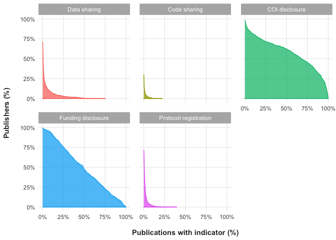

```r
indicator_by_publisher %>%
  mutate(indicator = fct_relevel(indicator, "Data sharing")) %>%
  ggplot(aes(x = p, color = indicator, fill = indicator)) +
  stat_ecdf(aes(y = 1 - ..y..), geom = "area", alpha = 0.75, pad = F) +
  scale_y_continuous(
    labels = scales::percent,
    limits = c(0, 1),
    name = "Publishers (%)\n"
  ) +
  scale_x_continuous(
    labels = scales::percent,
    name = "\nPublications with indicator (%)"
  ) +
  facet_wrap(~ indicator) +
  theme(
    legend.position = "none",
    panel.grid.minor = element_blank(),
    panel.spacing = unit(1, "lines")
  )
```

```r
ggsave(
  "../../output/figure_output/indicator-eval_indicator-by-publisher.jpg",
  width = 10,
  height = 6
)
```

## Research

Table - since 1990, ≥100 publications.

```r
indicator_by_publisher_art <-
  pmc %>%
  select(year, is_art, publisher, !!!indicator_vars) %>%
  filter(year >= 1990 & is_art) %>%
  add_count(publisher, name = "n_publications") %>%
  filter(n_publications > 100) %>%
  rename(!!!indicator_vars_dic) %>%
  gather(indicator, value, -year, -publisher, -is_art, -n_publications) %>%
  group_by(publisher, indicator) %>%
  summarise_at(vars(value), list(n = sum, p = mean))

indicator_by_publisher_art %>%
  group_by(indicator) %>%
  summarise_at(vars(p), list(
    above_100 = ~ sum_prop(., 1),
    above_90 = ~ sum_prop(., 0.9),
    above_75 = ~ sum_prop(., 0.75),
    above_70 = ~ sum_prop(., 0.7),
    above_50 = ~ sum_prop(., 0.5),
    above_25 = ~ sum_prop(., 0.25),
    above_10 = ~ sum_prop(., 0.10),
    at_0 = ~ sum_prop(., 0, at = T),
    above_0 = ~ sum_prop(., 0)
  )) %>%
  gather(key, value, -indicator) %>%
  pivot_wider(names_from = indicator, values_from = value) %>%
  sable(full_width = T)
```

| key | Code sharing | COI disclosure | Data sharing | Funding disclosure | Protocol registration |
| --- | --- | --- | --- | --- | --- |
| above_100 | 0 (0.0%) | 46 (8.0%) | 0 (0.0%) | 12 (2.1%) | 0 (0.0%) |
| above_90 | 0 (0.0%) | 204 (35.4%) | 0 (0.0%) | 80 (13.9%) | 0 (0.0%) |
| above_75 | 0 (0.0%) | 280 (48.5%) | 1 (0.2%) | 163 (28.2%) | 0 (0.0%) |
| above_70 | 0 (0.0%) | 297 (51.5%) | 1 (0.2%) | 190 (32.9%) | 0 (0.0%) |
| above_50 | 0 (0.0%) | 364 (63.1%) | 4 (0.7%) | 307 (53.2%) | 0 (0.0%) |
| above_25 | 0 (0.0%) | 419 (72.6%) | 22 (3.8%) | 444 (76.9%) | 2 (0.3%) |
| above_10 | 5 (0.9%) | 471 (81.6%) | 55 (9.5%) | 546 (94.6%) | 18 (3.1%) |
| at_0 | 403 (69.8%) | 12 (2.1%) | 162 (28.1%) | 5 (0.9%) | 163 (28.2%) |
| above_0 | 577 (100.0%) | 577 (100.0%) | 577 (100.0%) | 577 (100.0%) | 577 (100.0%) |

Plot.

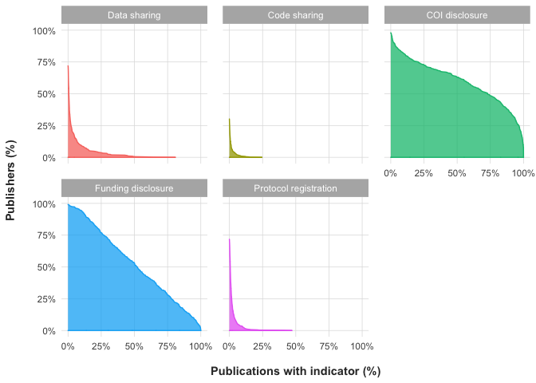

```r
indicator_by_publisher_art %>%
  mutate(indicator = fct_relevel(indicator, "Data sharing")) %>%
  ggplot(aes(x = p, color = indicator, fill = indicator)) +
  stat_ecdf(aes(y = 1 - ..y..), geom = "area", alpha = 0.75, pad = F) +
  scale_y_continuous(
    labels = scales::percent,
    limits = c(0, 1),
    name = "Publishers (%)\n"
  ) +
  scale_x_continuous(
    labels = scales::percent,
    name = "\nPublications with indicator (%)"
  ) +
  facet_wrap(~ indicator) +
  theme(
    legend.position = "none",
    panel.grid.minor = element_blank(),
    panel.spacing = unit(1, "lines")
  )
```

```r
ggsave(
  "../../output/figure_output/indicator-eval_indicator-by-publisher_art.jpg",
  width = 10,
  height = 6
)
```

## Ranking

Data - research articles.

```r
pmc %>%
  filter(year >= 1990 & is_art) %>%
  add_count(publisher) %>%
  mutate(N = n) %>%
  group_by(publisher, N) %>%
  summarise_at(vars(is_data_pred), list(n = sum, p = mean)) %>%
  select(publisher, n, N, p) %>%
  filter(N > 99) %>%
  arrange(desc(p), desc(n)) %>%
  mutate(p = scales::percent(p, accuracy = 0.1)) %>%
  head(20) %>%
  sable(full_width = T)
```

| publisher | n | N | p |
| --- | --- | --- | --- |
| Cold Spring Harbor Laboratory Press | 185 | 229 | 80.8% |
| American Society of Microbiology | 10131 | 15820 | 64.0% |
| The Royal Society Publishing | 3946 | 6671 | 59.2% |
| Genetics Society of America | 1543 | 3049 | 50.6% |
| PeerJ Inc. | 4068 | 8277 | 49.1% |
| the Japanese Society of Microbial Ecology (JSME)/the Japanese Society of Soil Microbiology (JSSM)/the Taiwan Society of Microbial Ecology (TSME)/the Japanese Society of Plant Microbe Interactions (JSP… | 124 | 255 | 48.6% |
| Japanese Society of Microbial Ecology/The Japanese Society of Soil Microbiology | 76 | 167 | 45.5% |
| National Academy of Sciences | 1282 | 2852 | 45.0% |
| Microbiology Society | 287 | 643 | 44.6% |
| Cell Press | 1576 | 3602 | 43.8% |
| Life Science Alliance LLC | 108 | 253 | 42.7% |
| CBS Fungal Biodiversity Centre | 72 | 217 | 33.2% |
| The American Society for Biochemistry and Molecular Biology | 229 | 714 | 32.1% |
| International Mycological Association | 49 | 153 | 32.0% |
| Michigan State University | 131 | 438 | 29.9% |
| Korea Health Personnel Licensing Examination Institute | 40 | 134 | 29.9% |
| eLife Sciences Publications, Ltd | 184 | 621 | 29.6% |
| Public Library of Science | 73729 | 249856 | 29.5% |
| F1000 Research Limited | 804 | 2757 | 29.2% |
| Royal Society of Chemistry | 1469 | 5627 | 26.1% |

Code - research articles.

```r
pmc %>%
  filter(year >= 1990 & is_art) %>%
  add_count(publisher) %>%
  mutate(N = n) %>%
  group_by(publisher, N) %>%
  summarise_at(vars(is_code_pred), list(n = sum, p = mean)) %>%
  select(publisher, n, N, p) %>%
  filter(N > 99) %>%
  arrange(desc(p), desc(n)) %>%
  mutate(p = scales::percent(p, accuracy = 0.1)) %>%
  head(20) %>%
  sable(full_width = T)
```

| publisher | n | N | p |
| --- | --- | --- | --- |
| MIT Press | 33 | 135 | 24.4% |
| Research Network of Computational and Structural Biotechnology | 29 | 191 | 15.2% |
| F1000 Research Limited | 408 | 2757 | 14.8% |
| Genetics Society of America | 376 | 3049 | 12.3% |
| Microbiology Society | 77 | 643 | 12.0% |
| Cell Press | 352 | 3602 | 9.8% |
| National Academy of Sciences | 244 | 2852 | 8.6% |
| PeerJ Inc. | 689 | 8277 | 8.3% |
| The Royal Society Publishing | 525 | 6671 | 7.9% |
| Society for Neuroscience | 96 | 1410 | 6.8% |
| The Biophysical Society | 11 | 163 | 6.7% |
| Oxford University Press | 3356 | 56389 | 6.0% |
| Life Science Alliance LLC | 14 | 253 | 5.5% |
| American Psychological Association | 19 | 346 | 5.5% |
| American Medical Informatics Association | 24 | 452 | 5.3% |
| eLife Sciences Publications, Ltd | 32 | 621 | 5.2% |
| Botanical Society of America | 23 | 475 | 4.8% |
| IEEE | 12 | 260 | 4.6% |
| Korea Genome Organization | 11 | 247 | 4.5% |
| The American Society for Biochemistry and Molecular Biology | 30 | 714 | 4.2% |

COI - any publication.

```r
pmc %>%
  filter(year >= 1990) %>%
  add_count(publisher) %>%
  mutate(N = n) %>%
  group_by(publisher, N) %>%
  summarise_at(vars(is_coi_pred), list(n = sum, p = mean)) %>%
  select(publisher, n, N, p) %>%
  filter(N > 99) %>%
  arrange(desc(p), desc(n)) %>%
  mutate(p = scales::percent(p, accuracy = 0.1)) %>%
  head(20) %>%
  sable(full_width = T)
```

| publisher | n | N | p |
| --- | --- | --- | --- |
| National Academy of Sciences | 2907 | 2907 | 100.0% |
| Ferrata Storti Foundation | 666 | 666 | 100.0% |
| University of California Irvine, Department of Emergency Medicine publishing Western Journal of Emergency Medicine | 402 | 402 | 100.0% |
| Institute of Immunobiology and Human Genetics | 271 | 271 | 100.0% |
| The Korean Society of Gastroenterology; the Korean Society of Gastrointestinal Endoscopy; the Korean Association for the Study of the Liver; the Korean Society of Neurogastroenterology and Motility; K… | 226 | 226 | 100.0% |
| Society of Diabetic Nephropathy Prevention | 213 | 213 | 100.0% |
| Nickan Research Institute | 196 | 196 | 100.0% |
| The Japanese Society for Spine Surgery and Related Research | 167 | 167 | 100.0% |
| Gut and Liver | 153 | 153 | 100.0% |
| Journal of Dentistry Shiraz University of Medical Sciences | 153 | 153 | 100.0% |
| Medicine Reports Ltd | 153 | 153 | 100.0% |
| SAGEYA | 141 | 141 | 100.0% |
| Shiraz University | 130 | 130 | 100.0% |
| Istanbul University Faculty of Dentisty | 102 | 102 | 100.0% |
| F1000 Research Limited | 4478 | 4483 | 99.9% |
| ID Design 2012/DOOEL Skopje | 1394 | 1396 | 99.9% |
| Baishideng Publishing Group Inc | 5580 | 5589 | 99.8% |
| Cases Network Ltd | 539 | 540 | 99.8% |
| Korean Society of Gastrointestinal Endoscopy | 439 | 440 | 99.8% |
| Veterinary World | 1299 | 1302 | 99.8% |

Funding - any publication.

```r
pmc %>%
  filter(year >= 1990) %>%
  add_count(publisher) %>%
  mutate(N = n) %>%
  group_by(publisher, N) %>%
  summarise_at(vars(is_fund_pred), list(n = sum, p = mean)) %>%
  select(publisher, n, N, p) %>%
  filter(N > 99) %>%
  arrange(desc(p), desc(n)) %>%
  mutate(p = scales::percent(p, accuracy = 0.1)) %>%
  head(20) %>%
  sable(full_width = T)
```

| publisher | n | N | p |
| --- | --- | --- | --- |
| SAGEYA | 141 | 141 | 100.0% |
| Company of Biologists | 124 | 124 | 100.0% |
| Istanbul University Faculty of Dentisty | 102 | 102 | 100.0% |
| ID Design 2012/DOOEL Skopje | 1392 | 1396 | 99.7% |
| PeerJ Inc. | 8497 | 8524 | 99.7% |
| EL-MED-Pub | 614 | 616 | 99.7% |
| AAI | 161 | 162 | 99.4% |
| PsychOpen | 224 | 226 | 99.1% |
| Bioscientifica Ltd | 1647 | 1662 | 99.1% |
| Society of Diabetic Nephropathy Prevention | 211 | 213 | 99.1% |
| Korean Association for the Study of Intestinal Diseases | 433 | 439 | 98.6% |
| American Association for the Advancement of Science | 4011 | 4069 | 98.6% |
| American Society for Nutrition | 331 | 337 | 98.2% |
| Life Science Alliance LLC | 266 | 271 | 98.2% |
| The British Editorial Society of Bone & Joint Surgery | 183 | 187 | 97.9% |
| Sociedade Brasileira de Angiologia e de Cirurgia Vascular (SBACV) | 182 | 186 | 97.8% |
| European Publishing on behalf of the International Society for the Prevention of Tobacco Induced Diseases (ISPTID) | 172 | 176 | 97.7% |
| Columbia University Libraries/Information Services | 426 | 436 | 97.7% |
| American Chemical Society and American Society of Pharmacognosy | 106 | 109 | 97.2% |
| Nickan Research Institute | 190 | 196 | 96.9% |

Registration - research articles.

```r
pmc %>%
  filter(year >= 1990 & is_art) %>%
  add_count(publisher) %>%
  mutate(N = n) %>%
  group_by(publisher, N) %>%
  summarise_at(vars(is_register_pred), list(n = sum, p = mean)) %>%
  select(publisher, n, N, p) %>%
  filter(N > 99) %>%
  arrange(desc(p), desc(n)) %>%
  mutate(p = scales::percent(p, accuracy = 0.1)) %>%
  head(20) %>%
  sable(full_width = T)
```

| publisher | n | N | p |
| --- | --- | --- | --- |
| Lancet Publishing Group | 174 | 370 | 47.0% |
| American Society for Nutrition | 106 | 262 | 40.5% |
| BMJ Publishing Group | 6253 | 27716 | 22.6% |
| JMIR Publications | 1453 | 6910 | 21.0% |
| Ferrata Storti Foundation | 100 | 614 | 16.3% |
| Kashan University of Medical Sciences | 20 | 132 | 15.2% |
| JAIDS Journal of Acquired Immune Deficiency Syndromes | 41 | 302 | 13.6% |
| American Medical Association | 155 | 1199 | 12.9% |
| Korean Society of Anesthesiologists | 19 | 156 | 12.2% |
| Gunther Eysenbach | 101 | 851 | 11.9% |
| Electronic physician | 102 | 900 | 11.3% |
| Associacao Brasileira de Pesquisa e Pos-Graduacao em Fisioterapia | 22 | 197 | 11.2% |
| American Society of Clinical Oncology | 71 | 637 | 11.1% |
| Endocrine Society | 92 | 845 | 10.9% |
| W.B. Saunders | 18 | 174 | 10.3% |
| Shiraz University of Medical Sciences | 101 | 985 | 10.3% |
| European Respiratory Society | 92 | 900 | 10.2% |
| Japan Atherosclerosis Society | 32 | 320 | 10.0% |
| Korean Society of Clinical Nutrition | 10 | 101 | 9.9% |
| Editorial Office of Gut and Liver | 32 | 335 | 9.6% |

# Save

```r
# Save
remove(pmcoa, pmc, meta)
save(list = ls(), file = "../../output/data_output/indicator-eval.RData")
```

# Documentation

## References

```
[[1]]
R Core Team (2019). _R: A Language and Environment for Statistical
Computing_. R Foundation for Statistical Computing, Vienna, Austria.
<URL: https://www.R-project.org/>.

[[2]]
Robinson D, Hayes A (2019). _broom: Convert Statistical Analysis
Objects into Tidy Tibbles_. R package version 0.5.2, <URL:
https://CRAN.R-project.org/package=broom>.

[[3]]
Wei T, Simko V (2017). _R package "corrplot": Visualization of a
Correlation Matrix_. (Version 0.84), <URL:
https://github.com/taiyun/corrplot>.

[[4]]
Wickham H, François R, Henry L, Müller K (2020). _dplyr: A Grammar of
Data Manipulation_. R package version 0.8.5, <URL:
https://CRAN.R-project.org/package=dplyr>.

[[5]]
Wickham H (2019). _forcats: Tools for Working with Categorical
Variables (Factors)_. R package version 0.4.0, <URL:
https://CRAN.R-project.org/package=forcats>.

[[6]]
Wickham H (2016). _ggplot2: Elegant Graphics for Data Analysis_.
Springer-Verlag New York. ISBN 978-3-319-24277-4, <URL:
https://ggplot2.tidyverse.org>.

[[7]]
Zhu H (2019). _kableExtra: Construct Complex Table with 'kable' and
Pipe Syntax_. R package version 1.1.0, <URL:
https://CRAN.R-project.org/package=kableExtra>.

[[8]]
Xie Y (2020). _knitr: A General-Purpose Package for Dynamic Report
Generation in R_. R package version 1.28, <URL:
https://yihui.org/knitr/>.

```

[output cut: 42 more lines]

```
Wickham H, Henry L (2020). _tidyr: Tidy Messy Data_. R package version
1.1.0, <URL: https://CRAN.R-project.org/package=tidyr>.

[[17]]
Wickham H, Averick M, Bryan J, Chang W, McGowan LD, François R,
Grolemund G, Hayes A, Henry L, Hester J, Kuhn M, Pedersen TL, Miller E,
Bache SM, Müller K, Ooms J, Robinson D, Seidel DP, Spinu V, Takahashi
K, Vaughan D, Wilke C, Woo K, Yutani H (2019). "Welcome to the
tidyverse." _Journal of Open Source Software_, *4*(43), 1686. doi:
10.21105/joss.01686 (URL: https://doi.org/10.21105/joss.01686).

[[18]]
Hester J, Wickham H (2020). _vroom: Read and Write Rectangular Text
Data Quickly_. R package version 1.2.0, <URL:
https://CRAN.R-project.org/package=vroom>.
```